# The SP survey

Start Date: 2020-11-07 Finish Date: Ongoing

### 전반적으로 쓰이는 패키지 호출

```r
library(dplyr) #Data Modifying, Grouping, and so on
library(tidyr) #Reshape between Wide and Long form

library(mlogit) #Logit Model
library(lmtest) #Logit Model fittness

library(ggplot2) #Draw Plot
# library(plotly) #More detailed Plot
library(gridExtra) #Show table in Plot
library(ggpubr) #Show multiple Plots
library(corrplot) #Draw Correlation Plot

library(showtext) #show Korean in Plot
#---cf. https://www.facebook.com/groups/krstudy/permalink/1546879218819678/?comment_id=1549629918544608
# system(command="wget wget http://cdn.naver.com/naver/NanumFont/fontfiles/NanumFont_TTF_ALL.zip")
# system(command="unzip NanumFont_TTF_ALL.zip -d NanumFont")
# system(command="rm -f NanumFont_TTF_ALL.zip")
#
font_add(family="NanumGothic", regular="NanumFont/NanumGothic.ttf", bold="NanumFont/NanumGothicBold.ttf")
showtext_auto()

# pdf("plots.pdf") #save a plot as PDF that can be edited in InDesign
# dev.off()
```

## 원시데이터 입력

### 설문 응답(.xlxs) 자료 입력

```r
colnm <- c("ResponseID", "TripL_mode_car", "TripL_mode_expbus", "TripL_mode_train", "TripL_mode_expt", "TripL_mode_plane", "TripL_mode_ship", "TripL_mode_none", "TripL_expt", "TripL_plane", "Trip_made", "Conv", "Eco", "Safe", "Trans", "New", "Sens", "SpA150_1", "SpA150_2", "SpA150_3", "SpA150_4", "SpA250_1", "SpA250_2", "SpA250_3", "SpA250_4", "SpA300_1", "SpA300_2", "SpA300_3", "SpA300_4", "SpB150_1", "SpB150_2", "SpB150_3", "SpB150_4", "SpB250_1", "SpB250_2", "SpB250_3", "SpB250_4", "SpB300_1", "SpB300_2", "SpB300_3", "SpB300_4", "Gender", "Byear", "HHsize", "Job", "Inc", "Ncars", "TypeError", "Type", "StartDate", "SubmitDate", "NetworkID")

coltp <- c("text", "text", "text", "text", "text", "text", "text", "text", "numeric", "numeric", "text", "numeric", "numeric", "numeric", "numeric", "numeric", "numeric", "text", "text", "text", "text", "text", "text", "text", "text", "text", "text", "text", "text", "text", "text", "text", "text", "text", "text", "text", "text", "text", "text", "text", "text", "text", "numeric", "numeric", "text", "text", "text", "numeric", "text", "text", "text", "text")

library(readxl)
data <- read_excel("responses.xlsx", col_names=colnm, col_types=coltp, skip=1)
# View(data)

remove(colnm, coltp)
```

### 선택지 한국어 → 데이터화 기준

```r
library(readxl)
level <- read_excel("Level.xlsx")
option <- read_excel("Option.xlsx")
```

## 데이터 1차 가공

```r
# filter only needed columns
colnm_f <- c("ResponseID", "TripL_mode_car", "TripL_mode_expbus", "TripL_mode_train", "TripL_mode_expt", "TripL_mode_plane", "TripL_mode_ship", "TripL_mode_none", "TripL_expt", "TripL_plane", "Trip_made", "Conv", "Eco", "Safe", "Trans", "New", "Sens", "SpA150_1","SpA150_2", "SpA150_3", "SpA150_4", "SpA250_1", "SpA250_2", "SpA250_3", "SpA250_4", "SpA300_1", "SpA300_2", "SpA300_3", "SpA300_4", "SpB150_1", "SpB150_2", "SpB150_3", "SpB150_4", "SpB250_1", "SpB250_2", "SpB250_3", "SpB250_4", "SpB300_1", "SpB300_2", "SpB300_3", "SpB300_4", "Gender", "Byear", "HHsize", "Job", "Inc", "Ncars", "Type")

dt <- data[colnames(data) %in% colnm_f]
remove(colnm_f)


# convert T/F(NA) to 1/0
colnm_t <- c("TripL_mode_car", "TripL_mode_expbus", "TripL_mode_train", "TripL_mode_expt", "TripL_mode_plane", "TripL_mode_ship", "TripL_mode_none")

for(c in colnames(dt)){
  if(c %in% colnm_t){
    dt[[c]][!is.na(dt[[c]])] <- 1
    dt[[c]][is.na(dt[[c]])] <- 0
  }
}
remove(c, colnm_t)


# remove non-target-sample
dt <- dt[dt$TripL_mode_none == 0, ]


# convert Korean to Number(char)
for(c in colnames(option)[!(colnames(option) %in% c("Number", "SelectN"))]){
  for(i in which(!is.na(option[[c]]))){
    # cat(option[i, c], sep="\n")
    # cat(option[i, "Number"], sep="\n")
    dt[] <- lapply(dt, function(x) gsub(option[i, c], option[i, "Number"], x, fixed=TRUE)) #fixed=TRUE means non-regex
  }
}
remove(i, c)


# change Character to Number except columns(ResponseID, Type)
dt <- dt %>% mutate_at(vars(-ResponseID, -Type), as.numeric)


# change+add Byear to Age
dt$Age <- 2020 - dt$Byear
dt <- dt[, which(colnames(dt) != "Byear")]

# change+add Age to Age-Interval and Boolean
dt$AgeI <- (dt$Age %/% 10) * 10
dt$Age20 <- ifelse(dt$Age %/% 10 == 2, 1, 0)

# change+add Job to Boolean
dt$Job8 <- ifelse(dt$Job == 8, 1, 0)
```

## 표본 특성

표본의 특성을 분석

Plot Template @[R graph gallery](https://www.r-graph-gallery.com/128-ring-or-donut-plot.html)

```r
AttType <- dt[, "Type"]
AttTrip <- dt[, match("TripL_mode_car", colnames(dt)):
                match("Trip_made", colnames(dt))]
AttLatent <- dt[, match("Conv", colnames(dt)):
                  match("Sens", colnames(dt))]
AttPerson <- dt[, match("Gender", colnames(dt)):
                  ncol(dt)]

# # Total Number of Samples
# nOfSmp <- nrow(dt)

# Number of Types: A, B
AttType %>% count(Type)
```

| Type | n |
| --- | --- |
| A | 37 |
| B | 41 |

### 분석 도표 출력 함수 정의

```r
# Draw Plot of 'data' grouped by 'group_var' and label with 'unit'(Korean)
getPlot <- function(data, group_var, header_str, bool_label=FALSE, label_TF) {
  group_var_str <- deparse(substitute(group_var))
  group_var_quo <- enquo(group_var)

  smmry <- data %>% group_by(!!group_var_quo) %>%
    summarise(Count=n(), Percentage=round(n()/nrow(data)*100,2))

  # Compute the cumulative percentages (top of each rectangle)
  smmry$ymax <- cumsum(smmry$Percentage)

  # Compute the bottom of each rectangle
  smmry$ymin <- c(0, head(smmry$ymax, n=-1))

  # Compute label position
  smmry$labelPosition <- (smmry$ymax + smmry$ymin) / 2

  # Compute a good label
  smmry$label <- paste0(smmry[[group_var_str]], "\n", smmry$Count, "명, ", smmry$Percentage, "%")

  # Make the plot
  color <- topo.colors(nrow(smmry))
  smmryPlot <- ggplot(smmry, aes(ymax=ymax, ymin=ymin, xmax=4, xmin=3, fill=color)) +
    geom_rect() +
    geom_text(x=7, aes(y=labelPosition, label=label, color=color), size=7, check_overlap=TRUE) +
    # x: label position (inner / outer)
    # size: text font size
    coord_polar(theta="y") + # Pie Chart
    xlim(c(-1, 8)) + # Donut Hole
    theme_void() +
    theme(legend.position = "none", text=element_text(family="NanumGothic"))

  # Show table
  if(bool_label){
    if(ifelse(missing(label_TF), group_var_str, label_TF) %in% colnames(option)){ # add information about Label(korean) of Number
      smmryTbl <- merge(option[which(!is.na(option[[ifelse(missing(label_TF), group_var_str, label_TF)]])),
                               which(colnames(option) %in% c("Number", ifelse(missing(label_TF), group_var_str, label_TF)))],
                        smmry[, 1:3], by.x="Number", by.y=group_var_str, all.x=TRUE) #Left Outer Join
    } else if(group_var_str == "Choice") {
      smmryTbl <- merge(option[which(!is.na(option[["Sp"]])),
                               which(colnames(option) %in% c("SpN", "Sp"))],
                        smmry[, 1:3], by.x="SpN", by.y=group_var_str, all.x=TRUE, sort=FALSE) #Left Outer Join
    } else if(deparse(substitute(data)) == "AttLatent") {
      dfLikert <- data.frame("Number"=1:7, "Meaning"=c("매우 아니다", "", "", "보통이다", "", "", "매우 그렇다"))
      smmryTbl <- merge(dfLikert, smmry[, 1:3], by.x="Number", by.y=group_var_str, all.x=TRUE) #Left Outer Join
    # } else { # Label(korean) is not in Option.xlsx
    #   dfBool <- data.frame("Number"=0:1, "Boolean"=c("틀림", "맞음"))
    #   smmryTbl <- merge(dfBool, smmry[, 1:3], by.x="Number", by.y=group_var_str, all.x=TRUE) #Left Outer Join
    }
    smmryTbl[is.na(smmryTbl)] <- 0
    smmryTblPlot <- tableGrob(smmryTbl, rows=NULL, cols=c("구분",
                                                          ifelse(missing(header_str), group_var_str, header_str),
                                                          "인원(명)", "비율(%)"),
                              theme=ttheme_default(base_family="NanumGothic", base_size=16))
  } else { # when Label(korean) is not needed
    smmryTblPlot <- tableGrob(smmry[, 1:3], rows=NULL,
                              cols=c(ifelse(missing(header_str), group_var_str, header_str), "인원(명)", "비율(%)"),
                              theme=ttheme_default(base_family="NanumGothic", base_size=16))
  }

  smmryArr <- ggarrange(smmryPlot, smmryTblPlot, ncol = 2, nrow = 1) # show graph and table together

  return(smmryArr)
}
```

### 개인 사회경제 변수

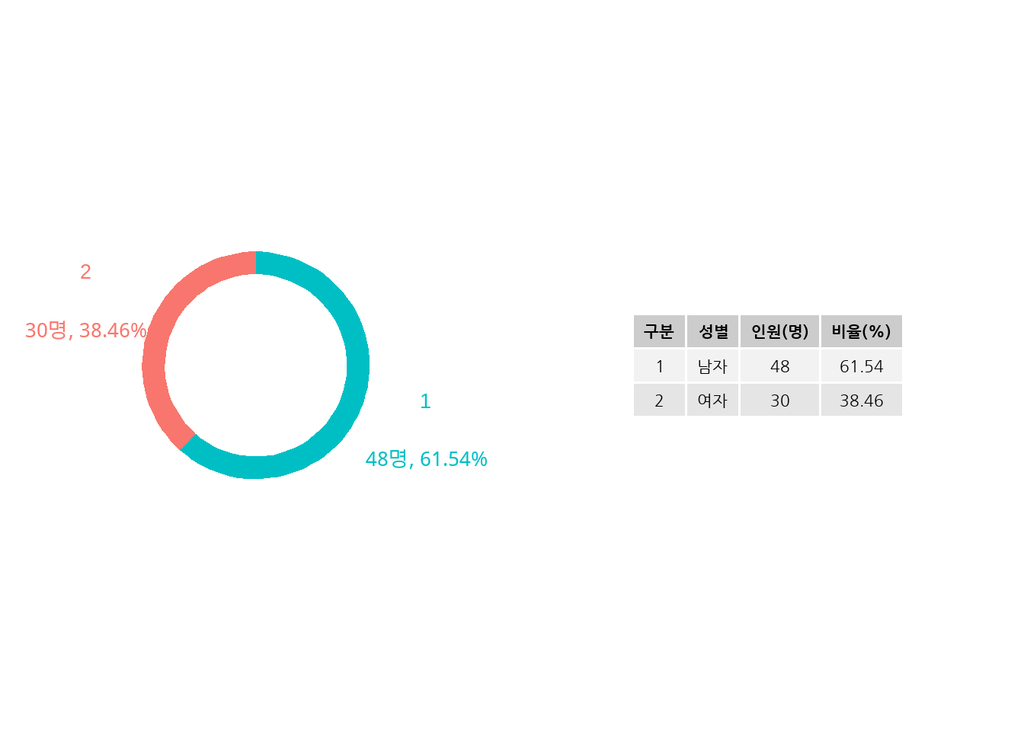

```r
getPlot(AttPerson, Gender, "성별", TRUE)
```

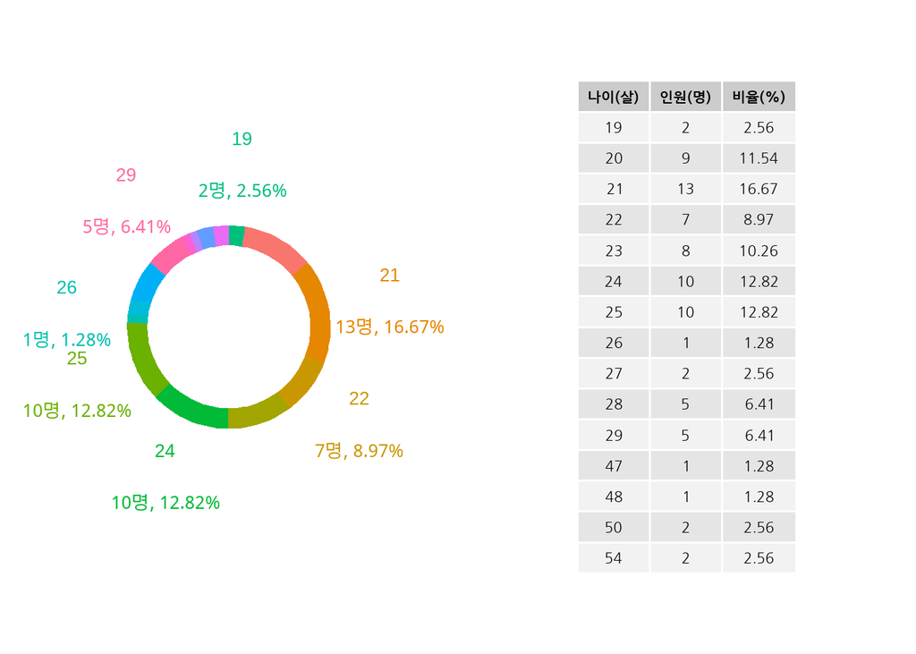

```r
getPlot(AttPerson, Age, "나이(살)")
```

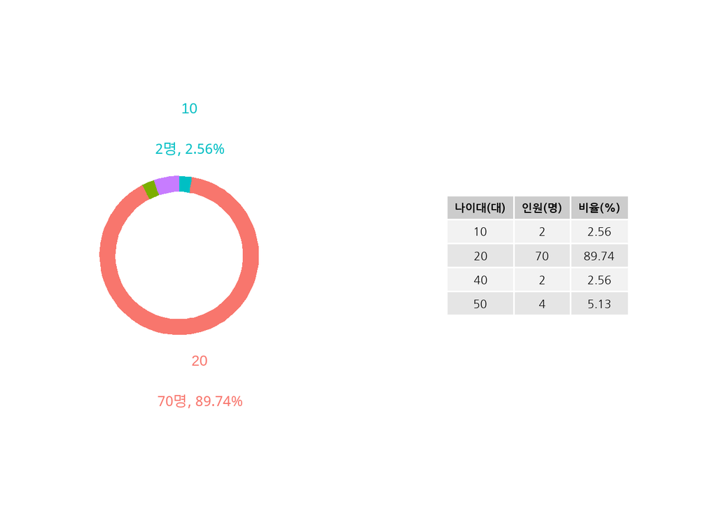

```r
getPlot(AttPerson, AgeI, "나이대(대)")
```

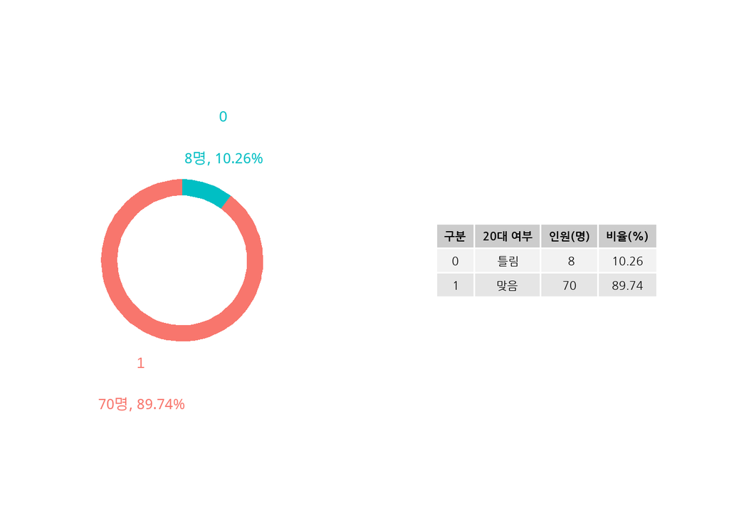

```r
getPlot(AttPerson, Age20, "20대 여부", TRUE, "TF")
```

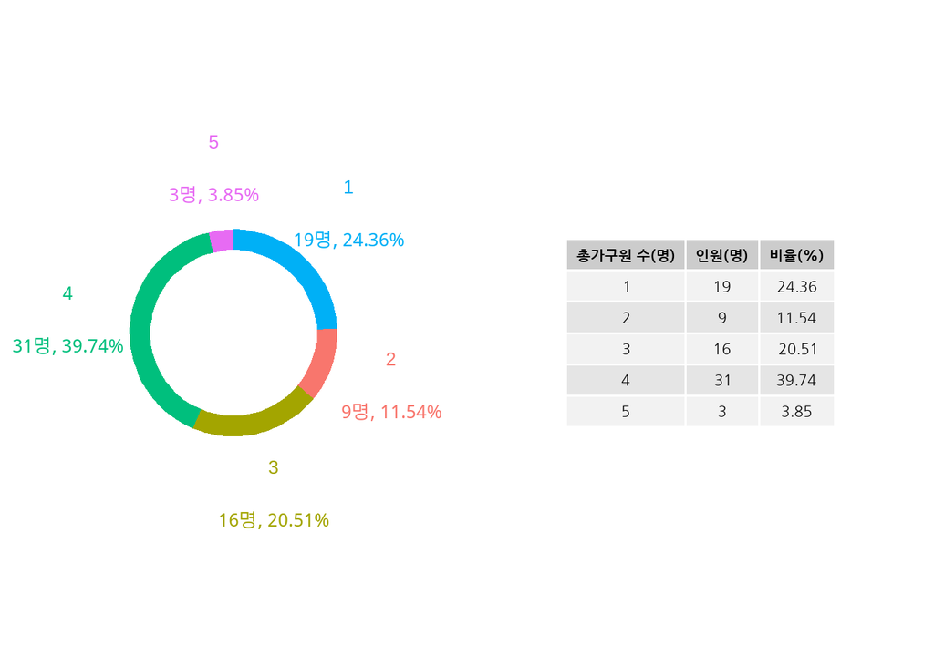

```r
getPlot(AttPerson, HHsize, "총가구원 수(명)")
```

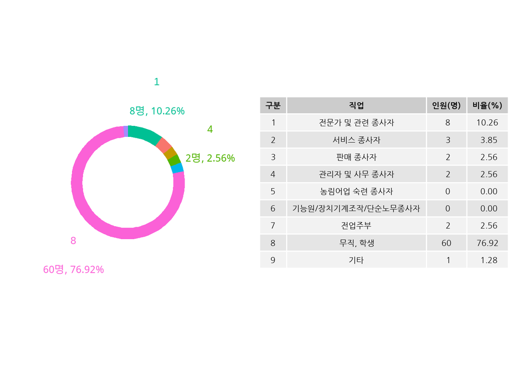

```r
getPlot(AttPerson, Job, "직업", TRUE)
```

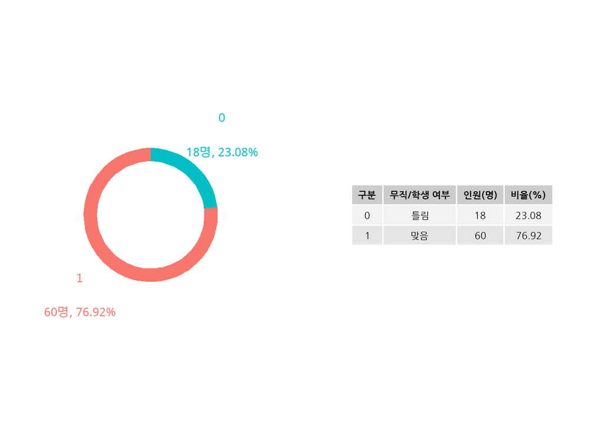

```r
getPlot(AttPerson, Job8, "무직/학생 여부", TRUE, "TF")
```

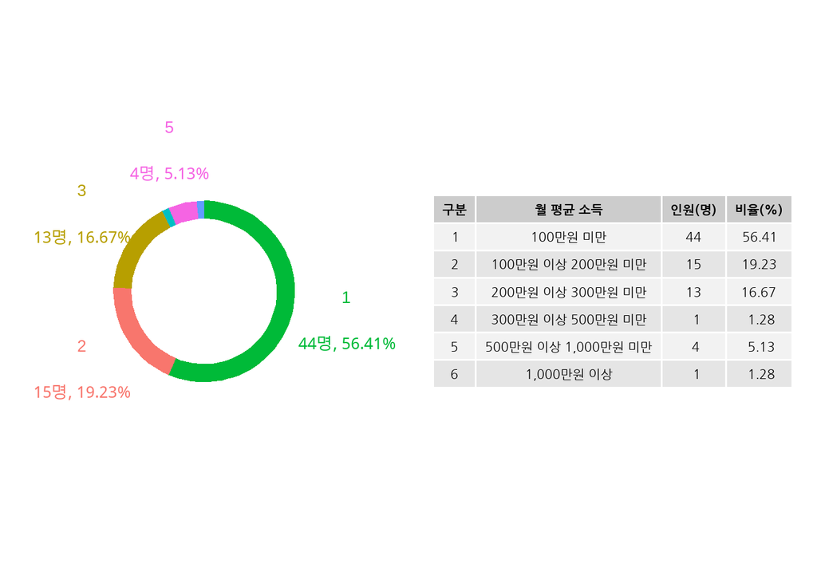

```r
getPlot(AttPerson, Inc, "월 평균 소득", TRUE)
```

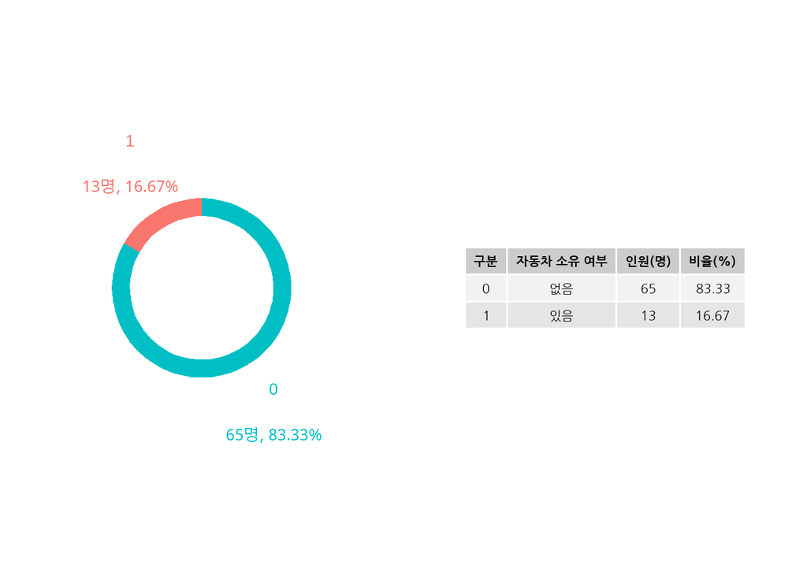

```r
getPlot(AttPerson, Ncars, "자동차 소유 여부", TRUE, "YN")
```

### 개인 통행특성 변수

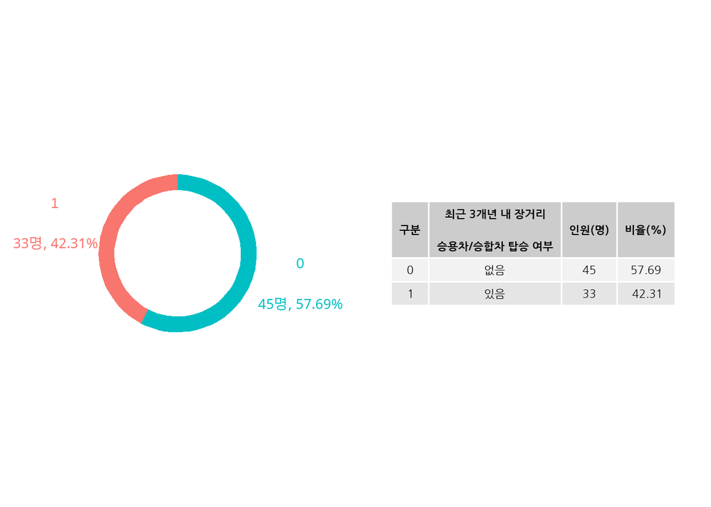

```r
# Have_experienced(1), None(0)
getPlot(AttTrip, TripL_mode_car, "최근 3개년 내 장거리\n승용차/승합차 탑승 여부", TRUE, "YN")
```

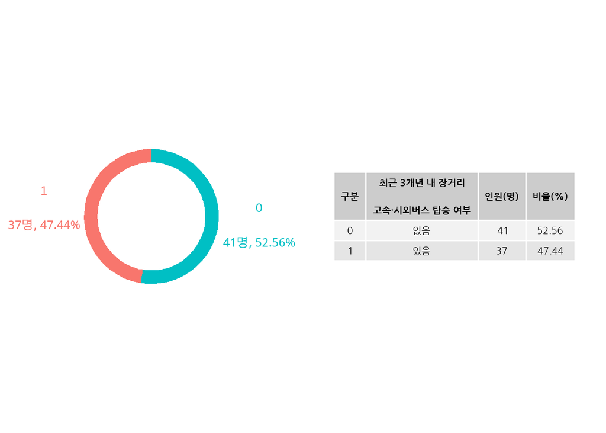

```r
getPlot(AttTrip, TripL_mode_expbus, "최근 3개년 내 장거리\n고속·시외버스 탑승 여부", TRUE, "YN")
```

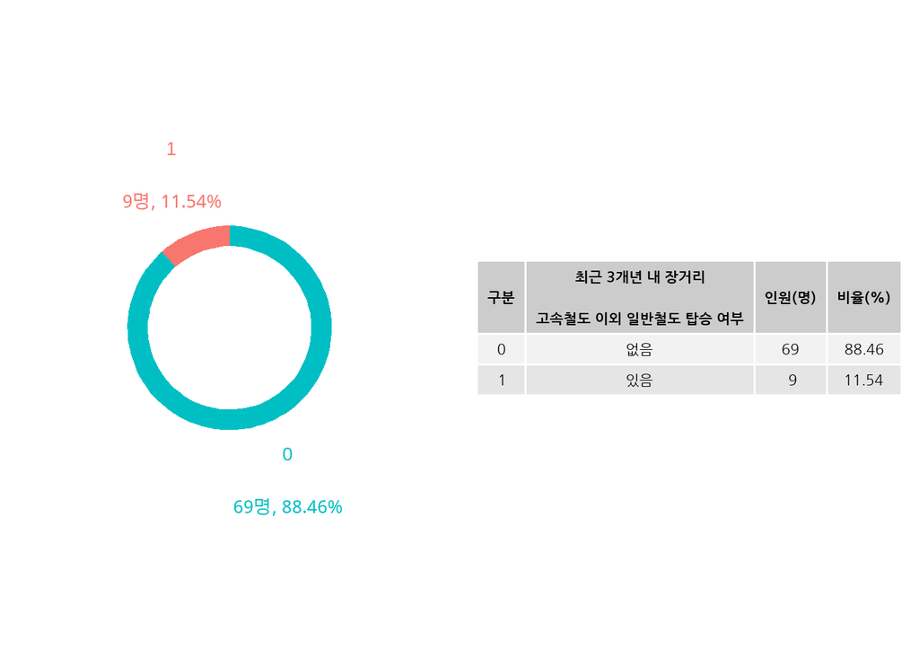

```r
getPlot(AttTrip, TripL_mode_train, "최근 3개년 내 장거리\n고속철도 이외 일반철도 탑승 여부", TRUE, "YN")
```

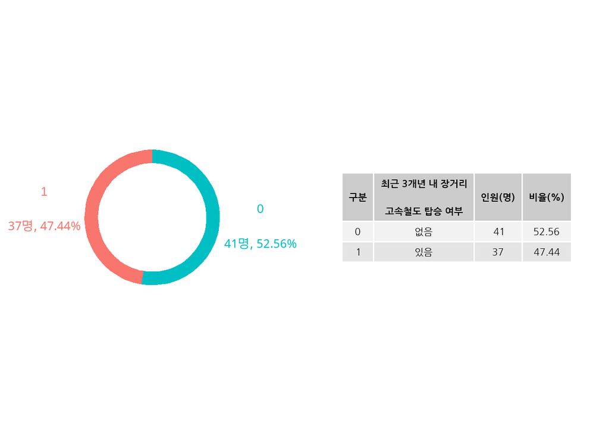

```r
getPlot(AttTrip, TripL_mode_expt, "최근 3개년 내 장거리\n고속철도 탑승 여부", TRUE, "YN")
```

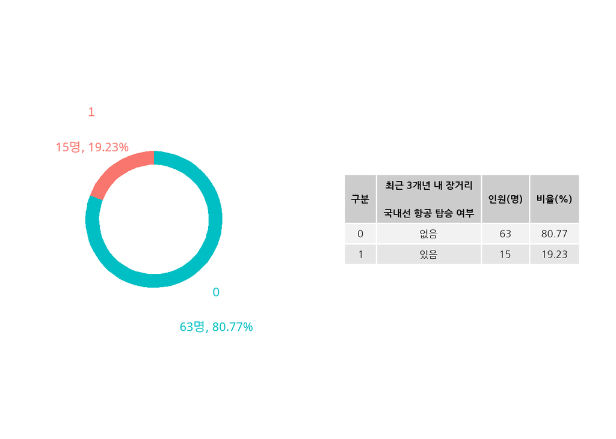

```r
getPlot(AttTrip, TripL_mode_plane, "최근 3개년 내 장거리\n국내선 항공 탑승 여부", TRUE, "YN")
```

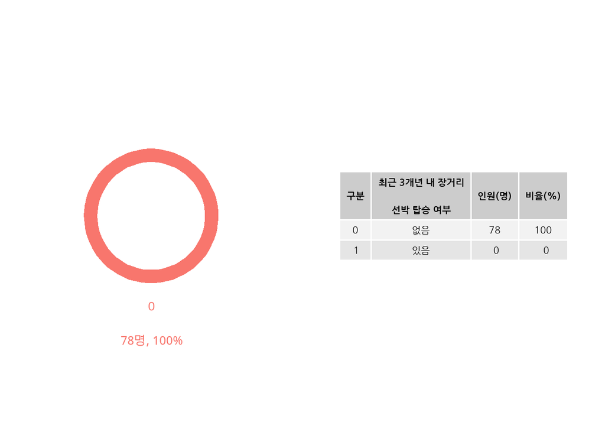

```r
getPlot(AttTrip, TripL_mode_ship, "최근 3개년 내 장거리\n선박 탑승 여부", TRUE, "YN")
```

### 개인 성향 변수

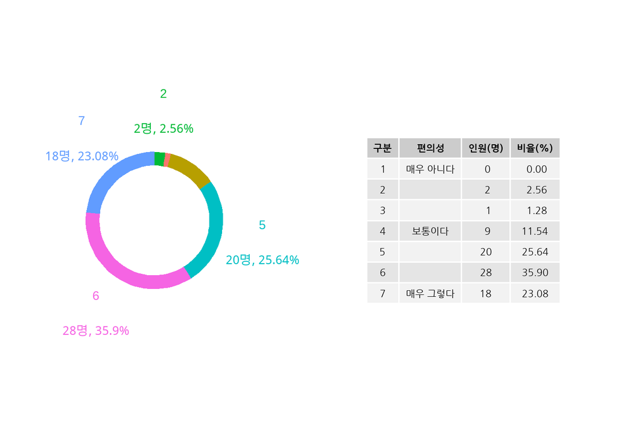

```r
getPlot(AttLatent, Conv, "편의성", TRUE)
```

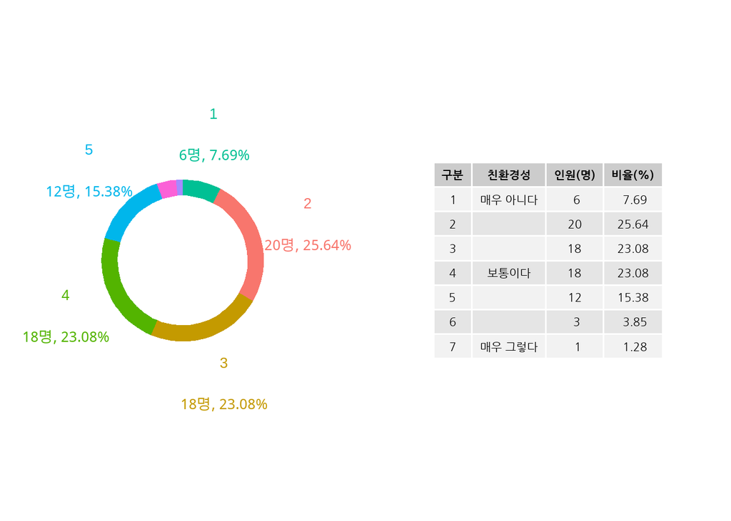

```r
getPlot(AttLatent, Eco, "친환경성", TRUE)
```

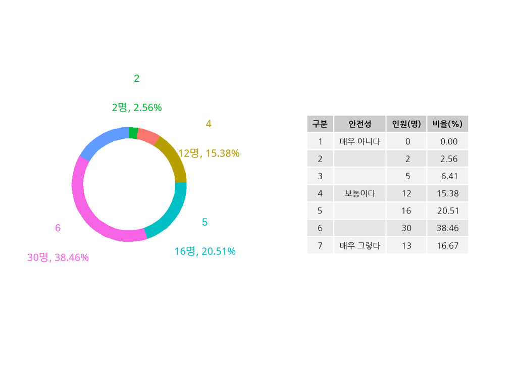

```r
getPlot(AttLatent, Safe, "안전성", TRUE)
```

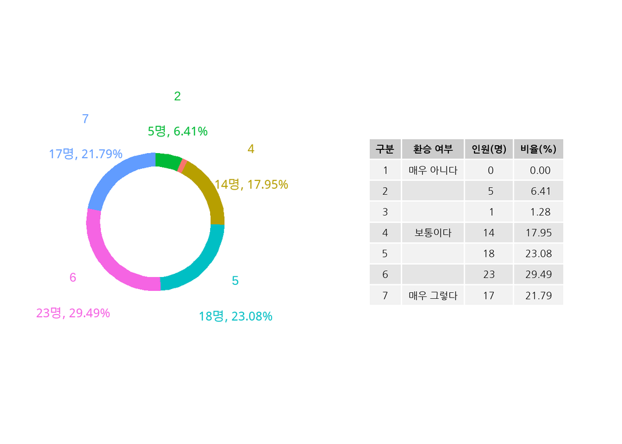

```r
getPlot(AttLatent, Trans, "환승 여부", TRUE)
```

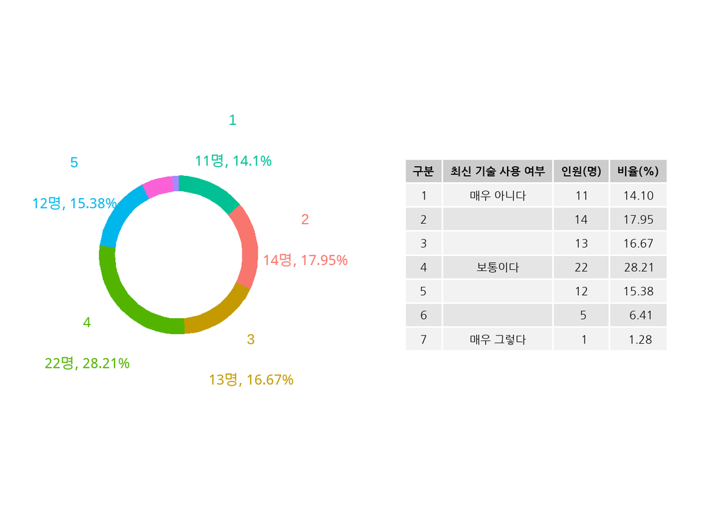

```r
getPlot(AttLatent, New, "최신 기술 사용 여부", TRUE)
```

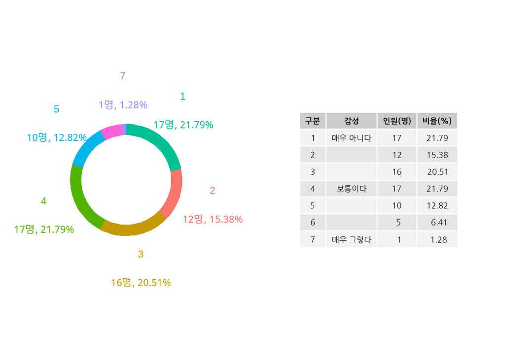

```r
getPlot(AttLatent, Sens, "감성", TRUE)
```

### 개인 성향 변수 사이의 상관관계 및 다중공선성 확인

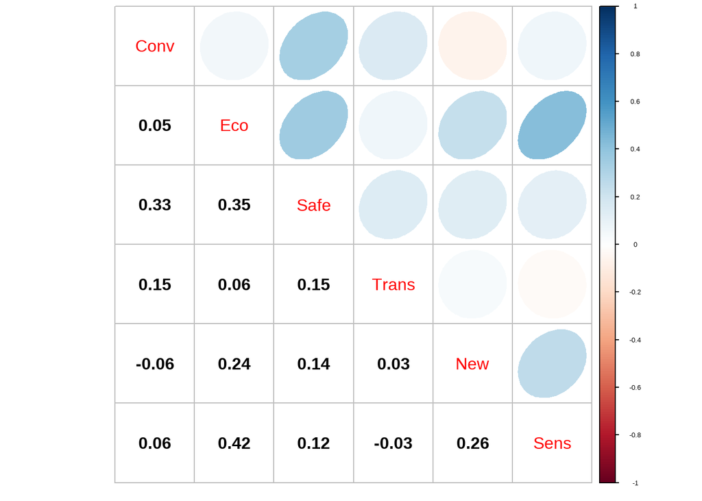

```r
# plot(AttLatent)
corrplot.mixed(cor(AttLatent), upper = "ellipse", lower.col = "black", tl.cex=2, number.cex=2)
```

## 로짓 모형

### 데이터 2차 가공 merge with Alternative Specific Variables’ levels

```r
colnm_sp <- c("SpA150_1","SpA150_2", "SpA150_3", "SpA150_4", "SpA250_1", "SpA250_2", "SpA250_3", "SpA250_4", "SpA300_1", "SpA300_2", "SpA300_3", "SpA300_4", "SpB150_1", "SpB150_2", "SpB150_3", "SpB150_4", "SpB250_1", "SpB250_2", "SpB250_3", "SpB250_4", "SpB300_1", "SpB300_2", "SpB300_3", "SpB300_4")

dtMerged <- dt %>% gather_('Question', 'Select', colnm_sp)
remove(colnm_sp)


# enter the "level" according to the Question Type
level$Question <- paste("Sp", level$Type, level$Dist, "_", level$Qq_ID, sep="")

# dtLong$Qtype <- substr(dtLong$Question, 3, 3)
# dtLong$Qdist <- as.numeric(substr(dtLong$Question, 4, 6))
# dtLong$QqqID <- as.numeric(substr(dtLong$Question, 8, 8))

dtMerged <- merge(dtMerged, level[, which(colnames(level)=="Dist"):ncol(level)],
           by="Question")


# remove non-answered-question
dtMerged <- dtMerged[!is.na(dtMerged$Select), ]


# convert Number to Name(character)
dtMerged <- merge(dtMerged, option[which(!is.na(option["SpN"])),
                                   which(colnames(option) %in% c("Number", "SpN"))], by.x="Select", by.y="Number")


# filter unneeded columns
dtMerged <- dtMerged[, which(!(colnames(dtMerged) %in% c("Select", "Question", "TripL_mode_none", "Type")))]


# change 'SpN' column name to 'Choice'
dtMerged <- rename(dtMerged, "Choice"="SpN")


str(dtMerged)
```

```
## 'data.frame':    936 obs. of  33 variables:
##  $ ResponseID       : chr  "1v4plkb9kp7ah8anjy3lrh1v4plkbejf" "017dtbw88uwzo4vwy84pbrj017dt8kll" "3hmip3nm6tq2pxk8u3hmip3yx9dinfqq" "esmmdodim73aaqcd508wp8esmmdoiq10" ...
##  $ TripL_mode_car   : num  1 0 1 1 0 0 1 1 0 0 ...
##  $ TripL_mode_expbus: num  0 0 1 0 0 1 1 1 0 1 ...
##  $ TripL_mode_train : num  1 0 1 0 0 0 0 0 0 0 ...
##  $ TripL_mode_expt  : num  0 1 1 1 1 0 1 0 1 0 ...
##  $ TripL_mode_plane : num  0 0 0 1 0 0 0 0 0 0 ...
##  $ TripL_mode_ship  : num  0 0 0 0 0 0 0 0 0 0 ...
##  $ TripL_expt       : num  1 1 1 1 1 0 1 1 1 0 ...
##  $ TripL_plane      : num  1 0 1 1 1 1 0 0 1 1 ...
##  $ Trip_made        : num  2 3 2 0 0 0 2 1 0 0 ...
##  $ Conv             : num  6 6 7 6 5 3 7 5 4 5 ...
##  $ Eco              : num  3 6 1 3 3 6 4 3 4 1 ...
##  $ Safe             : num  5 6 3 5 4 6 5 4 7 6 ...
##  $ Trans            : num  5 6 5 6 6 6 6 6 5 4 ...
```

[output cut: 19 more lines]

### 응답 특성

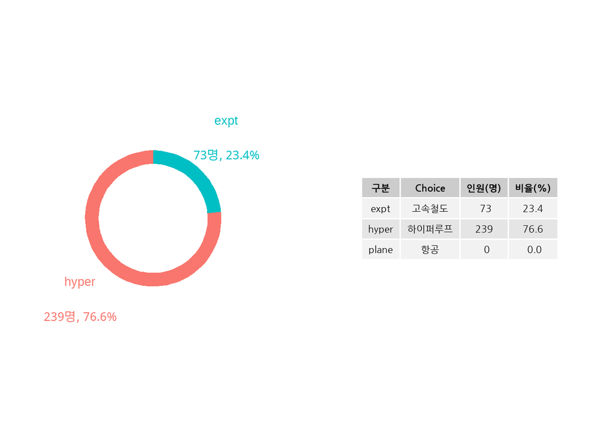

```r
AttSp <- dtMerged[, which(colnames(dtMerged) %in% c("Dist", "Choice"))]

# Total Number of Samples
# nOfSmp <- AttSp %>% count(Dist)
# nOfSmp <- nOfSmp[1, 2]

# Number of Choices by Distance: expt, plane, hyper
getPlot(AttSp %>% filter(Dist==150), Choice, , TRUE)
```

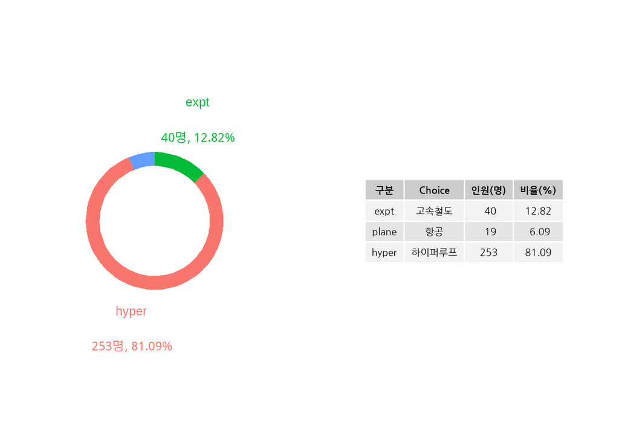

```r
getPlot(AttSp %>% filter(Dist==250), Choice, , TRUE)
```

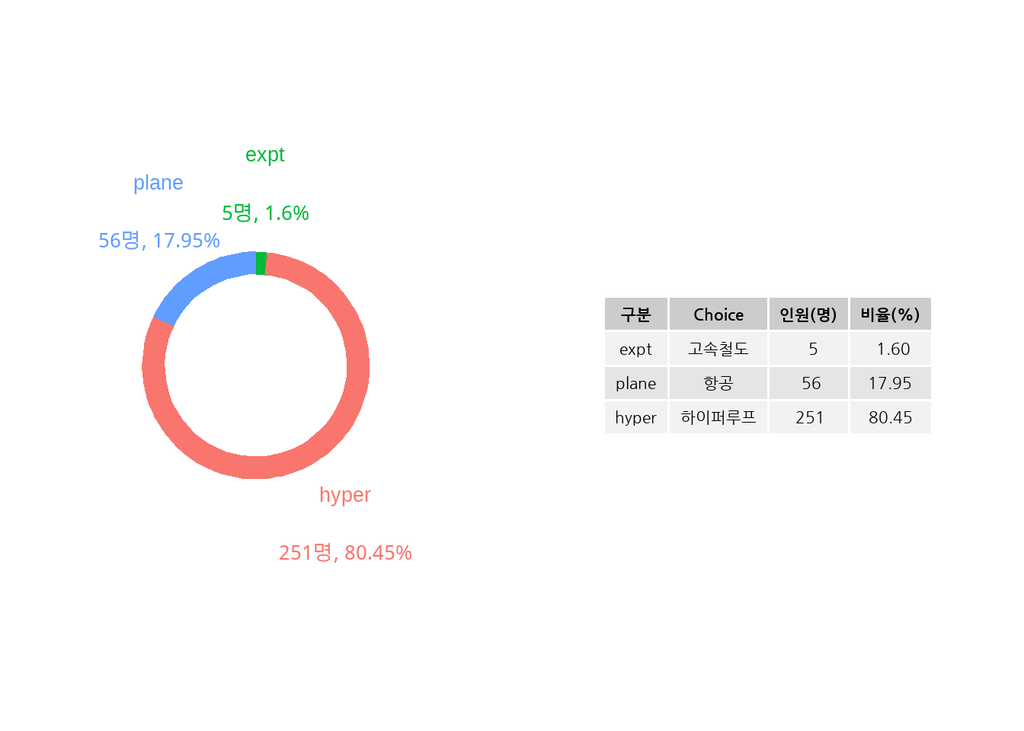

```r
getPlot(AttSp %>% filter(Dist==300), Choice, , TRUE)
```

### 데이터 3차 가공 to mlogit.Wide form

mlogit [기본 설명](https://cran.r-project.org/web/packages/mlogit/vignettes/c2.formula.data.html)

분석 및 해석하는 방법 [@Youtube](https://youtu.be/-Cp_KP9mq94)

```r
# Divide by Distance
dtMergedD <- dtMerged %>% group_split(Dist)


# Convert those to mlogit.Wide form
vars <- which(colnames(dtMerged) %in% c("Time_expt", "Time_plane", "Time_hyper", "Cost_expt", "Cost_plane", "Cost_hyper"))

dtWide <- mlogit.data(dtMerged, shape="wide", choice="Choice", varying=vars, sep="_", id.var="ResponseID")
dtWide$TimeToDist <- dtWide$Time / dtWide$Dist
dtWide$CostToDist <- dtWide$Cost / dtWide$Dist
dtWide250 <- mlogit.data(as.data.frame(dtMergedD[[2]]), shape="wide", choice="Choice", varying=vars, sep="_", id.var="ResponseID")


# without Plane in 150km
varsP <- which(colnames(dtMerged) %in% c("Time_expt", "Time_hyper", "Cost_expt", "Cost_hyper"))

dtWide150 <- mlogit.data(as.data.frame(dtMergedD[[1]]), shape="wide", choice="Choice", varying=varsP, sep="_", id.var="ResponseID")


# without Expt in 300km
varsE <- which(colnames(dtMerged) %in% c("Time_plane", "Time_hyper", "Cost_plane", "Cost_hyper"))

dtExcept <- dtMergedD[[3]][dtMergedD[[3]][, "Choice"] != "expt", ]
dtWide300 <- mlogit.data(as.data.frame(dtExcept), shape="wide", choice="Choice", varying=varsE, sep="_", id.var="ResponseID")


# head(index(dtWide))
#---chid: choice situation index
#---alt: alternative index
#---id: individual index

head(dtWide)
```

```
## ~~~~~~~
##  first 10 observations out of 2808
## ~~~~~~~
##                          ResponseID TripL_mode_car TripL_mode_expbus
## 1  017dtbw88uwzo4vwy84pbrj017dt8kll              0                 0
## 2  017dtbw88uwzo4vwy84pbrj017dt8kll              0                 0
## 3  017dtbw88uwzo4vwy84pbrj017dt8kll              0                 0
## 4  017dtbw88uwzo4vwy84pbrj017dt8kll              0                 0
## 5  017dtbw88uwzo4vwy84pbrj017dt8kll              0                 0
## 6  017dtbw88uwzo4vwy84pbrj017dt8kll              0                 0
## 7  017dtbw88uwzo4vwy84pbrj017dt8kll              0                 0
## 8  017dtbw88uwzo4vwy84pbrj017dt8kll              0                 0
## 9  017dtbw88uwzo4vwy84pbrj017dt8kll              0                 0
## 10 017dtbw88uwzo4vwy84pbrj017dt8kll              0                 0
##    TripL_mode_train TripL_mode_expt TripL_mode_plane TripL_mode_ship TripL_expt
```

[output cut: 57 more lines]

```r
dtWide[1:10, ]
```

```
##                          ResponseID TripL_mode_car TripL_mode_expbus
## 1  017dtbw88uwzo4vwy84pbrj017dt8kll              0                 0
## 2  017dtbw88uwzo4vwy84pbrj017dt8kll              0                 0
## 3  017dtbw88uwzo4vwy84pbrj017dt8kll              0                 0
## 4  017dtbw88uwzo4vwy84pbrj017dt8kll              0                 0
## 5  017dtbw88uwzo4vwy84pbrj017dt8kll              0                 0
## 6  017dtbw88uwzo4vwy84pbrj017dt8kll              0                 0
## 7  017dtbw88uwzo4vwy84pbrj017dt8kll              0                 0
## 8  017dtbw88uwzo4vwy84pbrj017dt8kll              0                 0
## 9  017dtbw88uwzo4vwy84pbrj017dt8kll              0                 0
## 10 017dtbw88uwzo4vwy84pbrj017dt8kll              0                 0
##    TripL_mode_train TripL_mode_expt TripL_mode_plane TripL_mode_ship TripL_expt
## 1                 0               1                0               0          1
## 2                 0               1                0               0          1
## 3                 0               1                0               0          1
```

[output cut: 54 more lines]

```r
remove(data, dt, vars, varsP, varsE)
# remove(level, option)
```

- `character` 문자형
- `categorical` 범주형
  - `t/f` 참/거짓
  - `nominal` 명칭척도
  - `ordinal` 순위척도
- `continuous` 연속형
  - `interval` 간격척도
  - `ratio` 비율척도

| 이름 | 유형 | 설명 | 내용 |
| --- | --- | --- | --- |
| `ResponseID` | char | 응답ID | 고유값 |
| `TripL_mode_car` | t/f | 3개년 내 장거리 승용차/승합차 탑승 여부 | 참/거짓 |
| `TripL_mode_expbus` | t/f | 3개년 내 장거리 고속·시외버스 탑승 여부 | 참/거짓 |
| `TripL_mode_train` | t/f | 3개년 내 장거리 일반철도 탑승 여부 | 참/거짓 |
| `TripL_mode_expt` | t/f | 3개년 내 장거리 고속철도 탑승 여부 | 참/거짓 |
| `TripL_mode_plane` | t/f | 3개년 내 장거리 항공 탑승 여부 | 참/거짓 |
| `TripL_mode_ship` | t/f | 3개년 내 장거리 선박 탑승 여부 | 참/거짓 |
| `TripL_expt` | t/f | 3개년 내 고속철도 탑승 여부 | 참/거짓 |
| `TripL_plane` | t/f | 3개년 내 항공 장거리 탑승 여부 | 참/거짓 |
| `Trip_made` | num | 월 평균 장거리 이동 왕복 횟수 | 횟수 |
| `Conv` | ordi | 편의성 | 1 < 7 |
| `Eco` | ordi | 친환경성 | 1 < 7 |
| `Safe` | ordi | 안전성 | 1 < 7 |
| `Trans` | ordi | 환승 여부 | 1 < 7 |
| `New` | ordi | 최신 기술 사용 여부 | 1 < 7 |
| `Sens` | ordi | 감성 | 1 < 7 |
| `Gender` | nomi | 성별 | 남자, 여자 |
| `HHsize` | num | 가구원수 | 명수 |
| `Job` | nomi | 직업 | 무직/학생(8) |
| `Job8` | t/f | 무직/학생 여부 | 참/거짓 |
| `Inc` | inte | 소득 | 100만원 미만(1) |
| `Ncars` | t/f | 자가용 보유 여부 | 참/거짓 |
| `Age` | rati | 나이 | 나이 |
| `AgeI` | rati | 나이대 | 대 |
| `Age20` | t/f | 20대 여부 | 참/거짓 |
| `Dist` | rati | 거리 | km |
| `Time` | rati | 시간 | 분 |
| `Cost` | rati | 비용 | 원 |
| `Choice` | nomi | 선택 | 고속철도(expt), 항공(plane), 하이퍼루프(hyper) |

### 효용함수 설정

```r
f <- mFormula(Choice ~ Cost | Gender + HHsize + Job + Inc + Ncars + Age + TripL_mode_car + TripL_mode_expbus + TripL_mode_train + TripL_mode_expt + TripL_mode_plane + TripL_expt + TripL_plane + Trip_made + Conv + Eco + Safe + Trans + New + Sens | Time)
f_D <- mFormula(Choice ~ Cost | Gender + HHsize + Job + Inc + Ncars + Age + TripL_mode_car + TripL_mode_expbus + TripL_mode_train + TripL_mode_expt + TripL_mode_plane + TripL_expt + TripL_plane + Trip_made + Conv + Eco + Safe + Trans + New + Sens | TimeToDist)
f_TD <- mFormula(Choice ~ Cost | Gender + HHsize + Job + Inc + Ncars + Age + TripL_mode_car + TripL_mode_expbus + TripL_mode_train + TripL_mode_expt + TripL_mode_plane + TripL_expt + TripL_plane + Trip_made + Conv + Eco + Safe + Trans + New + Sens | Time + TimeToDist)

f_AgeI <- mFormula(Choice ~ Cost | Gender + HHsize + Job + Inc + Ncars + AgeI + TripL_mode_car + TripL_mode_expbus + TripL_mode_train + TripL_mode_expt + TripL_mode_plane + TripL_expt + TripL_plane + Trip_made + Conv + Eco + Safe + Trans + New + Sens | Time)
f_TD_AgeI <- mFormula(Choice ~ Cost | Gender + HHsize + Job + Inc + Ncars + AgeI + TripL_mode_car + TripL_mode_expbus + TripL_mode_train + TripL_mode_expt + TripL_mode_plane + TripL_expt + TripL_plane + Trip_made + Conv + Eco + Safe + Trans + New + Sens | TimeToDist)

f_Age20 <- mFormula(Choice ~ Cost | Gender + HHsize + Job + Inc + Ncars + Age20 + TripL_mode_car + TripL_mode_expbus + TripL_mode_train + TripL_mode_expt + TripL_mode_plane + TripL_expt + TripL_plane + Trip_made + Conv + Eco + Safe + Trans + New + Sens | Time)
f_TD_Age20 <- mFormula(Choice ~ Cost | Gender + HHsize + Job + Inc + Ncars + Age20 + TripL_mode_car + TripL_mode_expbus + TripL_mode_train + TripL_mode_expt + TripL_mode_plane + TripL_expt + TripL_plane + Trip_made + Conv + Eco + Safe + Trans + New + Sens | TimeToDist)

f_Age20_Job8 <- mFormula(Choice ~ Cost | Gender + HHsize + Job8 + Inc + Ncars + Age20 + TripL_mode_car + TripL_mode_expbus + TripL_mode_train + TripL_mode_expt + TripL_mode_plane + TripL_expt + TripL_plane + Trip_made + Conv + Eco + Safe + Trans + New + Sens | Time)
f_TD_Age20_Job8 <- mFormula(Choice ~ Cost | Gender + HHsize + Job8 + Inc + Ncars + Age20 + TripL_mode_car + TripL_mode_expbus + TripL_mode_train + TripL_mode_expt + TripL_mode_plane + TripL_expt + TripL_plane + Trip_made + Conv + Eco + Safe + Trans + New + Sens | TimeToDist)

# f_latent <- mFormula(Choice ~ Cost | Gender + HHsize + Job + Inc + Ncars + Age + Conv + Eco + Safe + Trans + New + Sens | Time)
# f_latnet_ageI <- mFormula(Choice ~ Cost | Gender + HHsize + Job + Inc + Ncars + AgeI + Conv + Eco + Safe + Trans + New + Sens | Time)

# Dist 넣으면 에러 발생
# f <- mFormula(Choice ~ Dist | Gender + HHsize + Inc | Time)
```

### 로짓모형

```r
# m <- mlogit(f, dtWide, reflevel="hyper")
# summary(m)

# #fitted: estimated "probabilities to choose each specific mode"
# apply(fitted(m, type="probabilities", outcome=FALSE), 2, mean)

# mn <- with(m, data.frame(Cost=tapply(Cost, index(m)$Choice, mean)))

# lrtest(m)
# waldtest(m)
# scoretest(m)
#
#
# statpval <- function(x){
#     if (inherits(x, "anova")) result <- as.matrix(x)[2, c("Chisq", "Pr(>Chisq)")]
#     if (inherits(x, "htest")) result <- c(x$statistic, x$p.value)
#     names(result) <- c("stat", "p-value")
#     round(result, 3)
# }
#
# statpval(m)
```

#### ‘나이’ 변수 대입

```r
summary(mlogit(f, dtWide, reflevel="hyper"))
```

```
##
## Call:
## mlogit(formula = Choice ~ Cost | Gender + HHsize + Job + Inc +
##     Ncars + Age + TripL_mode_car + TripL_mode_expbus + TripL_mode_train +
##     TripL_mode_expt + TripL_mode_plane + TripL_expt + TripL_plane +
##     Trip_made + Conv + Eco + Safe + Trans + New + Sens | Time,
##     data = dtWide, reflevel = "hyper", method = "nr")
##
## Frequencies of alternatives:choice
##    hyper     expt    plane
## 0.793803 0.126068 0.080128
##
## nr method
## 7 iterations, 0h:0m:0s
## g'(-H)^-1g = 1.2E-05
## successive function values within tolerance limits
##
## Coefficients :
##                            Estimate  Std. Error  z-value  Pr(>|z|)
## (Intercept):expt        -1.1387e+00  1.5853e+00  -0.7183  0.472563
## (Intercept):plane       -1.3642e+00  3.4639e+00  -0.3938  0.693706
## Cost                    -1.2019e-04  1.0782e-05 -11.1471 < 2.2e-16 ***
## Gender:expt              1.2018e-01  2.6689e-01   0.4503  0.652496
## Gender:plane             1.3871e+00  3.3947e-01   4.0861 4.387e-05 ***
## HHsize:expt              4.4624e-02  1.0248e-01   0.4355  0.663229
## HHsize:plane            -6.4600e-02  1.2706e-01  -0.5084  0.611147
## Job:expt                -3.4456e-02  7.6898e-02  -0.4481  0.654097
## Job:plane               -4.6641e-02  9.3122e-02  -0.5009  0.616471
## Inc:expt                -3.6623e-01  2.0785e-01  -1.7620  0.078071 .
## Inc:plane               -4.7366e-01  2.4180e-01  -1.9588  0.050131 .
## Ncars:expt              -4.7990e-02  5.6950e-01  -0.0843  0.932843
## Ncars:plane             -1.1090e+00  9.0878e-01  -1.2203  0.222360
## Age:expt                 2.0959e-02  2.9147e-02   0.7191  0.472078
## Age:plane                4.2781e-02  3.9994e-02   1.0697  0.284768
## TripL_mode_car:expt     -6.4032e-01  2.7191e-01  -2.3549  0.018530 *
## TripL_mode_car:plane    -6.0718e-01  3.5625e-01  -1.7044  0.088316 .
## TripL_mode_expbus:expt   7.7550e-01  2.5353e-01   3.0588  0.002222 **
## TripL_mode_expbus:plane  4.3326e-01  3.1783e-01   1.3632  0.172832
## TripL_mode_train:expt    5.8221e-01  3.9048e-01   1.4910  0.135960
## TripL_mode_train:plane   7.4019e-01  4.8191e-01   1.5360  0.124547
```

[output cut: 16 more lines]

```
## Trans:expt              -1.5312e-02  9.0923e-02  -0.1684  0.866264
## Trans:plane              8.0256e-02  1.2138e-01   0.6612  0.508503
## New:expt                -8.5322e-02  8.4635e-02  -1.0081  0.313400
## New:plane               -2.9552e-01  1.1026e-01  -2.6802  0.007358 **
## Sens:expt               -1.5656e-01  8.9740e-02  -1.7445  0.081064 .
## Sens:plane              -1.1002e-01  1.1779e-01  -0.9341  0.350246
## Time:hyper              -3.8277e-02  1.8817e-02  -2.0342  0.041931 *
## Time:expt               -2.8513e-02  4.0090e-03  -7.1123 1.141e-12 ***
## Time:plane              -3.4674e-02  2.1837e-02  -1.5879  0.112313
## ---
## Signif. codes:  0 '***' 0.001 '**' 0.01 '*' 0.05 '.' 0.1 ' ' 1
##
## Log-Likelihood: -418.33
## McFadden R^2:  0.30884
## Likelihood ratio test : chisq = 373.85 (p.value = < 2.22e-16)
```

```r
summary(mlogit(f_D, dtWide, reflevel="hyper"))
```

```
##
## Call:
## mlogit(formula = Choice ~ Cost | Gender + HHsize + Job + Inc +
##     Ncars + Age + TripL_mode_car + TripL_mode_expbus + TripL_mode_train +
##     TripL_mode_expt + TripL_mode_plane + TripL_expt + TripL_plane +
##     Trip_made + Conv + Eco + Safe + Trans + New + Sens | TimeToDist,
##     data = dtWide, reflevel = "hyper", method = "nr")
##
## Frequencies of alternatives:choice
##    hyper     expt    plane
## 0.793803 0.126068 0.080128
##
## nr method
## 8 iterations, 0h:0m:0s
## g'(-H)^-1g = 0.000434
## successive function values within tolerance limits
##
## Coefficients :
##                            Estimate  Std. Error  z-value  Pr(>|z|)
## (Intercept):expt         6.9895e-01  2.3893e+00   0.2925 0.7698824
## (Intercept):plane        7.0198e-01  2.5669e+00   0.2735 0.7844869
## Cost                    -1.0330e-04  9.6237e-06 -10.7334 < 2.2e-16 ***
## Gender:expt              1.0451e-01  2.6486e-01   0.3946 0.6931473
## Gender:plane             1.3982e+00  3.4460e-01   4.0575 4.960e-05 ***
## HHsize:expt              4.1612e-02  1.0173e-01   0.4090 0.6825150
## HHsize:plane            -6.5606e-02  1.2858e-01  -0.5102 0.6098971
## Job:expt                -3.6864e-02  7.6174e-02  -0.4839 0.6284267
## Job:plane               -5.3168e-02  9.5007e-02  -0.5596 0.5757377
## Inc:expt                -3.5337e-01  2.0680e-01  -1.7087 0.0875004 .
## Inc:plane               -4.7796e-01  2.4585e-01  -1.9441 0.0518826 .
## Ncars:expt              -4.8644e-02  5.6474e-01  -0.0861 0.9313591
## Ncars:plane             -1.1315e+00  9.2194e-01  -1.2273 0.2197067
## Age:expt                 1.9967e-02  2.9061e-02   0.6871 0.4920348
## Age:plane                4.3433e-02  4.0679e-02   1.0677 0.2856621
## TripL_mode_car:expt     -6.2831e-01  2.6979e-01  -2.3288 0.0198678 *
## TripL_mode_car:plane    -6.1422e-01  3.5935e-01  -1.7092 0.0874079 .
## TripL_mode_expbus:expt   7.6360e-01  2.5185e-01   3.0320 0.0024291 **
## TripL_mode_expbus:plane  4.4979e-01  3.2180e-01   1.3977 0.1621958
## TripL_mode_train:expt    5.6911e-01  3.8686e-01   1.4711 0.1412693
## TripL_mode_train:plane   7.7011e-01  4.9177e-01   1.5660 0.1173513
```

[output cut: 16 more lines]

```
## Trans:expt              -2.0347e-02  9.0131e-02  -0.2258 0.8213945
## Trans:plane              8.3812e-02  1.2368e-01   0.6776 0.4980070
## New:expt                -8.4849e-02  8.3910e-02  -1.0112 0.3119298
## New:plane               -3.0814e-01  1.1215e-01  -2.7475 0.0060056 **
## Sens:expt               -1.5455e-01  8.8972e-02  -1.7371 0.0823705 .
## Sens:plane              -1.0918e-01  1.1905e-01  -0.9171 0.3590926
## TimeToDist:hyper        -1.3010e+01  1.9239e+00  -6.7622 1.359e-11 ***
## TimeToDist:expt         -1.0919e+01  3.3885e+00  -3.2223 0.0012716 **
## TimeToDist:plane        -1.4079e+01  3.6869e+00  -3.8187 0.0001341 ***
## ---
## Signif. codes:  0 '***' 0.001 '**' 0.01 '*' 0.05 '.' 0.1 ' ' 1
##
## Log-Likelihood: -417.08
## McFadden R^2:  0.3109
## Likelihood ratio test : chisq = 376.34 (p.value = < 2.22e-16)
```

```r
summary(mlogit(f_TD, dtWide, reflevel="hyper"))
```

```
##
## Call:
## mlogit(formula = Choice ~ Cost | Gender + HHsize + Job + Inc +
##     Ncars + Age + TripL_mode_car + TripL_mode_expbus + TripL_mode_train +
##     TripL_mode_expt + TripL_mode_plane + TripL_expt + TripL_plane +
##     Trip_made + Conv + Eco + Safe + Trans + New + Sens | Time +
##     TimeToDist, data = dtWide, reflevel = "hyper", method = "nr")
##
## Frequencies of alternatives:choice
##    hyper     expt    plane
## 0.793803 0.126068 0.080128
##
## nr method
## 8 iterations, 0h:0m:0s
## g'(-H)^-1g = 0.000394
## successive function values within tolerance limits
##
## Coefficients :
##                            Estimate  Std. Error  z-value  Pr(>|z|)
## (Intercept):expt         2.4662e+00  2.5731e+00   0.9585  0.337834
## (Intercept):plane        7.6619e+00  4.7854e+00   1.6011  0.109354
## Cost                    -1.1416e-04  1.1120e-05 -10.2668 < 2.2e-16 ***
## Gender:expt              9.6360e-02  2.6411e-01   0.3648  0.715224
## Gender:plane             1.4501e+00  3.5035e-01   4.1391 3.487e-05 ***
## HHsize:expt              4.3165e-02  1.0141e-01   0.4256  0.670368
## HHsize:plane            -6.5887e-02  1.3022e-01  -0.5060  0.612876
## Job:expt                -3.4492e-02  7.6060e-02  -0.4535  0.650200
## Job:plane               -5.1165e-02  9.6372e-02  -0.5309  0.595479
## Inc:expt                -3.5104e-01  2.0604e-01  -1.7038  0.088422 .
## Inc:plane               -4.9170e-01  2.4878e-01  -1.9764  0.048108 *
## Ncars:expt              -3.8750e-02  5.6300e-01  -0.0688  0.945127
## Ncars:plane             -1.1665e+00  9.3537e-01  -1.2471  0.212346
## Age:expt                 1.9886e-02  2.8890e-02   0.6883  0.491248
## Age:plane                4.4868e-02  4.1149e-02   1.0904  0.275544
## TripL_mode_car:expt     -6.2016e-01  2.6897e-01  -2.3057  0.021128 *
## TripL_mode_car:plane    -6.1681e-01  3.6395e-01  -1.6948  0.090122 .
## TripL_mode_expbus:expt   7.5362e-01  2.5100e-01   3.0025  0.002678 **
## TripL_mode_expbus:plane  4.4542e-01  3.2611e-01   1.3659  0.171982
## TripL_mode_train:expt    5.5508e-01  3.8597e-01   1.4381  0.150395
## TripL_mode_train:plane   7.7421e-01  4.9884e-01   1.5520  0.120656
```

[output cut: 19 more lines]

```
## New:plane               -3.1181e-01  1.1370e-01  -2.7424  0.006099 **
## Sens:expt               -1.5308e-01  8.8775e-02  -1.7243  0.084654 .
## Sens:plane              -1.0851e-01  1.2062e-01  -0.8996  0.368344
## Time:hyper              -1.4632e-02  5.2275e-02  -0.2799  0.779542
## Time:expt               -2.2904e-02  1.9890e-02  -1.1515  0.249507
## Time:plane              -5.7286e-02  3.0026e-02  -1.9079  0.056406 .
## TimeToDist:hyper        -1.3285e+00  9.8188e+00  -0.1353  0.892373
## TimeToDist:expt         -5.7061e+00  5.7253e+00  -0.9967  0.318932
## TimeToDist:plane        -1.0347e+01  5.8559e+00  -1.7669  0.077237 .
## ---
## Signif. codes:  0 '***' 0.001 '**' 0.01 '*' 0.05 '.' 0.1 ' ' 1
##
## Log-Likelihood: -411.98
## McFadden R^2:  0.31932
## Likelihood ratio test : chisq = 386.54 (p.value = < 2.22e-16)
```

```r
summary(mlogit(f, dtWide150, reflevel="hyper"))
```

```
##
## Call:
## mlogit(formula = Choice ~ Cost | Gender + HHsize + Job + Inc +
##     Ncars + Age + TripL_mode_car + TripL_mode_expbus + TripL_mode_train +
##     TripL_mode_expt + TripL_mode_plane + TripL_expt + TripL_plane +
##     Trip_made + Conv + Eco + Safe + Trans + New + Sens | Time,
##     data = dtWide150, reflevel = "hyper", method = "nr")
##
## Frequencies of alternatives:choice
##   hyper    expt
## 0.76603 0.23397
##
## nr method
## 6 iterations, 0h:0m:0s
## g'(-H)^-1g = 0.000365
## successive function values within tolerance limits
##
## Coefficients :
##                           Estimate  Std. Error z-value  Pr(>|z|)
## (Intercept):expt       -9.4770e+00  4.4288e+00 -2.1399   0.03237 *
## Cost                   -2.0915e-04  3.3608e-05 -6.2232 4.871e-10 ***
## Gender:expt            -2.4764e-01  3.9607e-01 -0.6252   0.53182
## HHsize:expt             1.1317e-01  1.4953e-01  0.7568   0.44916
## Job:expt                6.2863e-02  1.1285e-01  0.5571   0.57749
## Inc:expt               -2.1835e-01  2.9448e-01 -0.7415   0.45841
## Ncars:expt             -2.0708e-01  8.6910e-01 -0.2383   0.81167
## Age:expt                3.1496e-02  4.3036e-02  0.7318   0.46427
## TripL_mode_car:expt    -3.0013e-01  3.9919e-01 -0.7519   0.45213
## TripL_mode_expbus:expt  7.1658e-01  3.7346e-01  1.9188   0.05502 .
## TripL_mode_train:expt   1.2694e+00  5.7198e-01  2.2193   0.02647 *
## TripL_mode_expt:expt   -4.1807e-03  3.7758e-01 -0.0111   0.99117
## TripL_mode_plane:expt   4.3101e-01  5.0533e-01  0.8529   0.39370
## TripL_expt:expt         5.1755e-01  5.1179e-01  1.0113   0.31189
## TripL_plane:expt        3.1675e-01  4.1627e-01  0.7609   0.44670
## Trip_made:expt          8.1416e-02  1.7464e-01  0.4662   0.64108
## Conv:expt              -2.3401e-01  1.7612e-01 -1.3287   0.18395
## Eco:expt                3.8806e-01  1.6466e-01  2.3567   0.01844 *
## Safe:expt               1.0611e-01  1.6901e-01  0.6278   0.53012
## Trans:expt             -1.3922e-01  1.3150e-01 -1.0586   0.28976
## New:expt               -2.4517e-01  1.2793e-01 -1.9165   0.05531 .
## Sens:expt              -1.4768e-01  1.3547e-01 -1.0901   0.27565
## Time:hyper             -6.7688e-02  4.1201e-02 -1.6429   0.10041
## Time:expt               3.2971e-02  3.5090e-02  0.9396   0.34742
## ---
## Signif. codes:  0 '***' 0.001 '**' 0.01 '*' 0.05 '.' 0.1 ' ' 1
##
## Log-Likelihood: -112.37
## McFadden R^2:  0.33798
## Likelihood ratio test : chisq = 114.74 (p.value = 3.6454e-14)
```

```r
# summary(mlogit(f, dtWide250, reflevel="hyper"))
summary(mlogit(f, dtWide300, reflevel="hyper"))
```

```
##
## Call:
## mlogit(formula = Choice ~ Cost | Gender + HHsize + Job + Inc +
##     Ncars + Age + TripL_mode_car + TripL_mode_expbus + TripL_mode_train +
##     TripL_mode_expt + TripL_mode_plane + TripL_expt + TripL_plane +
##     Trip_made + Conv + Eco + Safe + Trans + New + Sens | Time,
##     data = dtWide300, reflevel = "hyper", method = "nr")
##
## Frequencies of alternatives:choice
##   hyper   plane
## 0.81759 0.18241
##
## nr method
## 7 iterations, 0h:0m:0s
## g'(-H)^-1g = 0.000199
## successive function values within tolerance limits
##
## Coefficients :
##                            Estimate  Std. Error z-value  Pr(>|z|)
## (Intercept):plane        2.4688e-01  5.9364e+00  0.0416  0.966828
## Cost                    -1.3255e-04  2.2886e-05 -5.7915 6.976e-09 ***
## Gender:plane             2.2810e+00  5.3323e-01  4.2778 1.888e-05 ***
## HHsize:plane            -2.5288e-01  1.6535e-01 -1.5294  0.126169
## Job:plane               -2.2007e-01  1.2154e-01 -1.8106  0.070196 .
## Inc:plane               -1.0092e+00  3.3457e-01 -3.0165  0.002557 **
## Ncars:plane             -3.3325e+00  1.4753e+00 -2.2589  0.023892 *
## Age:plane                1.5311e-01  5.8434e-02  2.6201  0.008790 **
## TripL_mode_car:plane    -5.6135e-01  4.5559e-01 -1.2321  0.217898
## TripL_mode_expbus:plane  7.2804e-01  4.3347e-01  1.6796  0.093043 .
## TripL_mode_train:plane  -4.3957e-01  7.0219e-01 -0.6260  0.531320
## TripL_mode_expt:plane   -8.2733e-02  4.4686e-01 -0.1851  0.853119
## TripL_mode_plane:plane  -4.2716e-01  5.6883e-01 -0.7509  0.452690
## TripL_expt:plane         3.2143e-01  5.6383e-01  0.5701  0.568623
## TripL_plane:plane        7.8510e-01  4.7189e-01  1.6637  0.096164 .
## Trip_made:plane          1.6718e-01  2.3293e-01  0.7177  0.472936
## Conv:plane              -1.9704e-01  2.2802e-01 -0.8641  0.387511
## Eco:plane                1.1628e-01  1.8866e-01  0.6163  0.537673
## Safe:plane              -2.7448e-01  2.0343e-01 -1.3493  0.177254
## Trans:plane             -9.6554e-02  1.5163e-01 -0.6368  0.524275
## New:plane               -3.8210e-01  1.5611e-01 -2.4477  0.014377 *
## Sens:plane               3.6669e-02  1.5717e-01  0.2333  0.815522
## Time:hyper              -3.1137e-02  3.6985e-02 -0.8419  0.399845
## Time:plane              -4.1208e-02  3.7059e-02 -1.1119  0.266165
## ---
## Signif. codes:  0 '***' 0.001 '**' 0.01 '*' 0.05 '.' 0.1 ' ' 1
##
## Log-Likelihood: -93.71
## McFadden R^2:  0.35742
## Likelihood ratio test : chisq = 104.25 (p.value = 2.5797e-12)
```

#### ‘나이대’ 변수 대입

```r
# summary(mlogit(f_AgeI, dtWide, reflevel="hyper"))
# summary(mlogit(f_AgeI, dtWide150, reflevel="hyper"))
# summary(mlogit(f_AgeI, dtWide250, reflevel="hyper"))
# summary(mlogit(f_AgeI, dtWide300, reflevel="hyper"))
```

#### ‘20대 여부’ 변수 대입

```r
summary(mlogit(f_Age20, dtWide, reflevel="hyper"))
```

```
##
## Call:
## mlogit(formula = Choice ~ Cost | Gender + HHsize + Job + Inc +
##     Ncars + Age20 + TripL_mode_car + TripL_mode_expbus + TripL_mode_train +
##     TripL_mode_expt + TripL_mode_plane + TripL_expt + TripL_plane +
##     Trip_made + Conv + Eco + Safe + Trans + New + Sens | Time,
##     data = dtWide, reflevel = "hyper", method = "nr")
##
## Frequencies of alternatives:choice
##    hyper     expt    plane
## 0.793803 0.126068 0.080128
##
## nr method
## 7 iterations, 0h:0m:0s
## g'(-H)^-1g = 1.01E-05
## successive function values within tolerance limits
##
## Coefficients :
##                            Estimate  Std. Error  z-value  Pr(>|z|)
## (Intercept):expt        -1.2958e+00  1.7105e+00  -0.7576 0.4487055
## (Intercept):plane       -5.6328e-01  3.6033e+00  -0.1563 0.8757798
## Cost                    -1.1972e-04  1.0749e-05 -11.1374 < 2.2e-16 ***
## Gender:expt              1.3475e-01  2.6989e-01   0.4993 0.6175736
## Gender:plane             1.3130e+00  3.3795e-01   3.8851 0.0001023 ***
## HHsize:expt              6.8131e-02  1.0471e-01   0.6507 0.5152640
## HHsize:plane            -5.4549e-02  1.3005e-01  -0.4194 0.6748902
## Job:expt                -2.6452e-02  7.6844e-02  -0.3442 0.7306767
## Job:plane               -3.8710e-02  9.3048e-02  -0.4160 0.6773965
## Inc:expt                -2.6019e-01  1.7907e-01  -1.4530 0.1462234
## Inc:plane               -3.5052e-01  2.1461e-01  -1.6332 0.1024189
## Ncars:expt               1.6429e-01  5.2344e-01   0.3139 0.7536185
## Ncars:plane             -6.4851e-01  7.7168e-01  -0.8404 0.4006953
## Age20:expt               3.4172e-01  5.3652e-01   0.6369 0.5241716
## Age20:plane             -8.5338e-02  6.6695e-01  -0.1280 0.8981863
## TripL_mode_car:expt     -6.6068e-01  2.7267e-01  -2.4230 0.0153928 *
## TripL_mode_car:plane    -6.0392e-01  3.5891e-01  -1.6826 0.0924460 .
## TripL_mode_expbus:expt   7.2140e-01  2.5307e-01   2.8506 0.0043640 **
## TripL_mode_expbus:plane  4.0757e-01  3.1699e-01   1.2858 0.1985296
## TripL_mode_train:expt    5.4010e-01  3.8767e-01   1.3932 0.1635662
## TripL_mode_train:plane   7.4443e-01  4.8028e-01   1.5500 0.1211390
```

[output cut: 16 more lines]

```
## Trans:expt              -2.4735e-02  9.2104e-02  -0.2686 0.7882753
## Trans:plane              8.0625e-02  1.2248e-01   0.6583 0.5103608
## New:expt                -7.5860e-02  8.5756e-02  -0.8846 0.3763709
## New:plane               -2.9708e-01  1.1390e-01  -2.6083 0.0090989 **
## Sens:expt               -1.5161e-01  8.8456e-02  -1.7140 0.0865378 .
## Sens:plane              -8.9060e-02  1.1538e-01  -0.7719 0.4401646
## Time:hyper              -3.8315e-02  1.8797e-02  -2.0383 0.0415159 *
## Time:expt               -2.8453e-02  4.0016e-03  -7.1104 1.157e-12 ***
## Time:plane              -3.4615e-02  2.1814e-02  -1.5869 0.1125395
## ---
## Signif. codes:  0 '***' 0.001 '**' 0.01 '*' 0.05 '.' 0.1 ' ' 1
##
## Log-Likelihood: -418.87
## McFadden R^2:  0.30794
## Likelihood ratio test : chisq = 372.76 (p.value = < 2.22e-16)
```

```r
summary(mlogit(f_Age20, dtWide150, reflevel="hyper"))
```

```
##
## Call:
## mlogit(formula = Choice ~ Cost | Gender + HHsize + Job + Inc +
##     Ncars + Age20 + TripL_mode_car + TripL_mode_expbus + TripL_mode_train +
##     TripL_mode_expt + TripL_mode_plane + TripL_expt + TripL_plane +
##     Trip_made + Conv + Eco + Safe + Trans + New + Sens | Time,
##     data = dtWide150, reflevel = "hyper", method = "nr")
##
## Frequencies of alternatives:choice
##   hyper    expt
## 0.76603 0.23397
##
## nr method
## 6 iterations, 0h:0m:0s
## g'(-H)^-1g = 0.000364
## successive function values within tolerance limits
##
## Coefficients :
##                           Estimate  Std. Error z-value  Pr(>|z|)
## (Intercept):expt       -9.9229e+00  4.5327e+00 -2.1892   0.02858 *
## Cost                   -2.0920e-04  3.3612e-05 -6.2239 4.848e-10 ***
## Gender:expt            -2.1287e-01  3.9987e-01 -0.5323   0.59449
## HHsize:expt             1.5282e-01  1.5333e-01  0.9967   0.31892
## Job:expt                8.0164e-02  1.1210e-01  0.7151   0.47455
## Inc:expt               -2.9373e-02  2.5105e-01 -0.1170   0.90686
## Ncars:expt              1.9496e-01  7.8476e-01  0.2484   0.80380
## Age20:expt              7.0273e-01  8.3671e-01  0.8399   0.40098
## TripL_mode_car:expt    -3.4750e-01  4.0019e-01 -0.8683   0.38521
## TripL_mode_expbus:expt  6.4477e-01  3.7277e-01  1.7297   0.08369 .
## TripL_mode_train:expt   1.1883e+00  5.6984e-01  2.0853   0.03704 *
## TripL_mode_expt:expt   -2.9946e-02  3.7601e-01 -0.0796   0.93652
## TripL_mode_plane:expt   3.3885e-01  5.1469e-01  0.6584   0.51031
## TripL_expt:expt         6.2216e-01  5.1921e-01  1.1983   0.23081
## TripL_plane:expt        2.6475e-01  4.0917e-01  0.6470   0.51761
## Trip_made:expt          6.3403e-02  1.7492e-01  0.3625   0.71700
## Conv:expt              -2.3135e-01  1.7575e-01 -1.3163   0.18807
## Eco:expt                3.7275e-01  1.6217e-01  2.2985   0.02153 *
## Safe:expt               1.3159e-01  1.6997e-01  0.7742   0.43881
## Trans:expt             -1.6678e-01  1.3334e-01 -1.2508   0.21100
## New:expt               -2.2882e-01  1.2936e-01 -1.7689   0.07691 .
## Sens:expt              -1.3472e-01  1.3306e-01 -1.0125   0.31130
## Time:hyper             -6.7897e-02  4.1232e-02 -1.6467   0.09962 .
## Time:expt               3.2041e-02  3.5130e-02  0.9121   0.36173
## ---
## Signif. codes:  0 '***' 0.001 '**' 0.01 '*' 0.05 '.' 0.1 ' ' 1
##
## Log-Likelihood: -112.27
## McFadden R^2:  0.33855
## Likelihood ratio test : chisq = 114.93 (p.value = 3.3644e-14)
```

```r
# summary(mlogit(f_Age20, dtWide250, reflevel="hyper"))
summary(mlogit(f_Age20, dtWide300, reflevel="hyper"))
```

```
##
## Call:
## mlogit(formula = Choice ~ Cost | Gender + HHsize + Job + Inc +
##     Ncars + Age20 + TripL_mode_car + TripL_mode_expbus + TripL_mode_train +
##     TripL_mode_expt + TripL_mode_plane + TripL_expt + TripL_plane +
##     Trip_made + Conv + Eco + Safe + Trans + New + Sens | Time,
##     data = dtWide300, reflevel = "hyper", method = "nr")
##
## Frequencies of alternatives:choice
##   hyper   plane
## 0.81759 0.18241
##
## nr method
## 7 iterations, 0h:0m:0s
## g'(-H)^-1g = 1.81E-05
## successive function values within tolerance limits
##
## Coefficients :
##                            Estimate  Std. Error z-value  Pr(>|z|)
## (Intercept):plane        2.7010e+00  6.1078e+00  0.4422   0.65833
## Cost                    -1.2158e-04  2.1005e-05 -5.7883 7.112e-09 ***
## Gender:plane             1.8448e+00  4.7248e-01  3.9046 9.439e-05 ***
## HHsize:plane            -2.0063e-01  1.6696e-01 -1.2016   0.22950
## Job:plane               -1.5679e-01  1.1527e-01 -1.3602   0.17377
## Inc:plane               -5.7962e-01  2.8279e-01 -2.0496   0.04040 *
## Ncars:plane             -1.1003e+00  9.9280e-01 -1.1083   0.26774
## Age20:plane             -3.0455e-01  8.5554e-01 -0.3560   0.72186
## TripL_mode_car:plane    -5.2437e-01  4.4372e-01 -1.1817   0.23731
## TripL_mode_expbus:plane  5.9017e-01  4.1062e-01  1.4373   0.15064
## TripL_mode_train:plane  -1.7429e-01  6.4848e-01 -0.2688   0.78811
## TripL_mode_expt:plane   -2.7452e-01  4.2134e-01 -0.6515   0.51471
## TripL_mode_plane:plane  -2.6186e-01  5.7385e-01 -0.4563   0.64816
## TripL_expt:plane         4.5876e-01  5.6569e-01  0.8110   0.41738
## TripL_plane:plane        4.5252e-01  4.4514e-01  1.0166   0.30935
## Trip_made:plane          1.3670e-02  2.2532e-01  0.0607   0.95162
## Conv:plane              -1.6869e-01  2.1895e-01 -0.7704   0.44104
## Eco:plane                5.5588e-02  1.7883e-01  0.3108   0.75592
## Safe:plane              -1.7805e-01  1.9349e-01 -0.9202   0.35746
## Trans:plane             -6.7769e-02  1.5083e-01 -0.4493   0.65320
## New:plane               -3.5029e-01  1.5316e-01 -2.2872   0.02219 *
## Sens:plane               1.1121e-01  1.5016e-01  0.7406   0.45896
## Time:hyper              -2.7140e-02  3.6228e-02 -0.7491   0.45377
## Time:plane              -3.7898e-02  3.6300e-02 -1.0440   0.29647
## ---
## Signif. codes:  0 '***' 0.001 '**' 0.01 '*' 0.05 '.' 0.1 ' ' 1
##
## Log-Likelihood: -97.468
## McFadden R^2:  0.33165
## Likelihood ratio test : chisq = 96.732 (p.value = 5.1325e-11)
```

#### ‘20대 여부’ 및 ‘무직, 학생 여부’ 변수 대입

```r
summary(mlogit(f_Age20_Job8, dtWide, reflevel="hyper"))
```

```
##
## Call:
## mlogit(formula = Choice ~ Cost | Gender + HHsize + Job8 + Inc +
##     Ncars + Age20 + TripL_mode_car + TripL_mode_expbus + TripL_mode_train +
##     TripL_mode_expt + TripL_mode_plane + TripL_expt + TripL_plane +
##     Trip_made + Conv + Eco + Safe + Trans + New + Sens | Time,
##     data = dtWide, reflevel = "hyper", method = "nr")
##
## Frequencies of alternatives:choice
##    hyper     expt    plane
## 0.793803 0.126068 0.080128
##
## nr method
## 7 iterations, 0h:0m:1s
## g'(-H)^-1g = 1.78E-05
## successive function values within tolerance limits
##
## Coefficients :
##                            Estimate  Std. Error  z-value  Pr(>|z|)
## (Intercept):expt        -0.39579740  1.60701085  -0.2463  0.805455
## (Intercept):plane        1.96400974  3.60578362   0.5447  0.585971
## Cost                    -0.00012089  0.00001081 -11.1832 < 2.2e-16 ***
## Gender:expt              0.14369068  0.27110254   0.5300  0.596096
## Gender:plane             1.39956295  0.35165424   3.9799 6.893e-05 ***
## HHsize:expt              0.12407741  0.10897051   1.1386  0.254856
## HHsize:plane             0.03301275  0.13708827   0.2408  0.809699
## Job8:expt               -1.10961956  0.54878074  -2.0220  0.043179 *
## Job8:plane              -2.12737026  0.71253433  -2.9856  0.002830 **
## Inc:expt                -0.46477158  0.20793754  -2.2351  0.025408 *
## Inc:plane               -0.73089194  0.28047866  -2.6059  0.009164 **
## Ncars:expt              -0.19830468  0.53379271  -0.3715  0.710264
## Ncars:plane             -1.69772474  0.85559117  -1.9843  0.047226 *
## Age20:expt               0.40531183  0.53424625   0.7587  0.448055
## Age20:plane             -0.06908105  0.68010859  -0.1016  0.919095
## TripL_mode_car:expt     -0.62477511  0.27270598  -2.2910  0.021962 *
## TripL_mode_car:plane    -0.49926687  0.36429660  -1.3705  0.170532
## TripL_mode_expbus:expt   0.64396190  0.25697750   2.5059  0.012214 *
## TripL_mode_expbus:plane  0.27083988  0.32773104   0.8264  0.408572
## TripL_mode_train:expt    0.49282141  0.38855345   1.2683  0.204673
## TripL_mode_train:plane   0.59963719  0.48227845   1.2433  0.213742
```

[output cut: 16 more lines]

```
## Trans:expt              -0.03118429  0.09222876  -0.3381  0.735274
## Trans:plane              0.04843257  0.12552448   0.3858  0.699614
## New:expt                -0.06813747  0.08728024  -0.7807  0.434994
## New:plane               -0.30372372  0.12122965  -2.5054  0.012233 *
## Sens:expt               -0.17707283  0.08682506  -2.0394  0.041408 *
## Sens:plane              -0.17635696  0.11735313  -1.5028  0.132894
## Time:hyper              -0.03934591  0.01895508  -2.0757  0.037918 *
## Time:expt               -0.02855542  0.00402241  -7.0991 1.256e-12 ***
## Time:plane              -0.03535725  0.02202500  -1.6053  0.108423
## ---
## Signif. codes:  0 '***' 0.001 '**' 0.01 '*' 0.05 '.' 0.1 ' ' 1
##
## Log-Likelihood: -412.52
## McFadden R^2:  0.31843
## Likelihood ratio test : chisq = 385.46 (p.value = < 2.22e-16)
```

```r
summary(mlogit(f_Age20_Job8, dtWide150, reflevel="hyper"))
```

```
##
## Call:
## mlogit(formula = Choice ~ Cost | Gender + HHsize + Job8 + Inc +
##     Ncars + Age20 + TripL_mode_car + TripL_mode_expbus + TripL_mode_train +
##     TripL_mode_expt + TripL_mode_plane + TripL_expt + TripL_plane +
##     Trip_made + Conv + Eco + Safe + Trans + New + Sens | Time,
##     data = dtWide150, reflevel = "hyper", method = "nr")
##
## Frequencies of alternatives:choice
##   hyper    expt
## 0.76603 0.23397
##
## nr method
## 6 iterations, 0h:0m:0s
## g'(-H)^-1g = 0.000371
## successive function values within tolerance limits
##
## Coefficients :
##                           Estimate  Std. Error z-value  Pr(>|z|)
## (Intercept):expt       -7.8205e+00  4.3870e+00 -1.7827   0.07464 .
## Cost                   -2.0923e-04  3.3651e-05 -6.2178 5.042e-10 ***
## Gender:expt            -2.3480e-01  4.0011e-01 -0.5868   0.55731
## HHsize:expt             2.0615e-01  1.5855e-01  1.3002   0.19355
## Job8:expt              -7.1790e-01  7.9029e-01 -0.9084   0.36367
## Inc:expt               -2.5615e-01  2.8382e-01 -0.9025   0.36677
## Ncars:expt             -2.8186e-01  8.0354e-01 -0.3508   0.72576
## Age20:expt              6.3805e-01  8.2117e-01  0.7770   0.43716
## TripL_mode_car:expt    -2.7246e-01  3.9894e-01 -0.6830   0.49463
## TripL_mode_expbus:expt  5.7329e-01  3.7861e-01  1.5142   0.12998
## TripL_mode_train:expt   1.0925e+00  5.6781e-01  1.9240   0.05436 .
## TripL_mode_expt:expt   -2.3850e-02  3.7805e-01 -0.0631   0.94970
## TripL_mode_plane:expt   3.1055e-01  5.1608e-01  0.6017   0.54735
## TripL_expt:expt         6.7452e-01  5.2443e-01  1.2862   0.19838
## TripL_plane:expt        1.9845e-01  4.0784e-01  0.4866   0.62655
## Trip_made:expt          8.5128e-02  1.7159e-01  0.4961   0.61982
## Conv:expt              -2.4141e-01  1.7636e-01 -1.3689   0.17104
## Eco:expt                3.8162e-01  1.6211e-01  2.3541   0.01857 *
## Safe:expt               1.1151e-01  1.6971e-01  0.6571   0.51114
## Trans:expt             -1.7192e-01  1.3354e-01 -1.2874   0.19795
## New:expt               -2.2306e-01  1.3015e-01 -1.7140   0.08654 .
## Sens:expt              -1.7828e-01  1.2997e-01 -1.3717   0.17016
## Time:hyper             -6.7675e-02  4.1262e-02 -1.6401   0.10098
## Time:expt               2.8836e-02  3.5043e-02  0.8229   0.41058
## ---
## Signif. codes:  0 '***' 0.001 '**' 0.01 '*' 0.05 '.' 0.1 ' ' 1
##
## Log-Likelihood: -112.11
## McFadden R^2:  0.33949
## Likelihood ratio test : chisq = 115.25 (p.value = 2.9513e-14)
```

```r
summary(mlogit(f_Age20_Job8, dtWide250, reflevel="hyper"))
```

```
##
## Call:
## mlogit(formula = Choice ~ Cost | Gender + HHsize + Job8 + Inc +
##     Ncars + Age20 + TripL_mode_car + TripL_mode_expbus + TripL_mode_train +
##     TripL_mode_expt + TripL_mode_plane + TripL_expt + TripL_plane +
##     Trip_made + Conv + Eco + Safe + Trans + New + Sens | Time,
##     data = dtWide250, reflevel = "hyper", method = "nr")
##
## Frequencies of alternatives:choice
##    hyper     expt    plane
## 0.810897 0.128205 0.060897
##
## nr method
## 7 iterations, 0h:0m:0s
## g'(-H)^-1g = 2.99E-07
## gradient close to zero
##
## Coefficients :
##                            Estimate  Std. Error z-value  Pr(>|z|)
## (Intercept):expt         2.3477e+01  7.1994e+00  3.2609 0.0011106 **
## (Intercept):plane        3.7246e+01  1.2860e+01  2.8963 0.0037760 **
## Cost                    -1.2016e-04  2.4647e-05 -4.8753 1.087e-06 ***
## Gender:expt              1.1174e+00  5.2580e-01  2.1252 0.0335687 *
## Gender:plane             1.0263e+00  7.9054e-01  1.2982 0.1942115
## HHsize:expt              1.0283e-01  2.0858e-01  0.4930 0.6220143
## HHsize:plane             3.1337e-01  2.9368e-01  1.0671 0.2859378
## Job8:expt               -1.5539e+00  1.1265e+00 -1.3795 0.1677547
## Job8:plane              -1.0043e+00  1.6645e+00 -0.6034 0.5462702
## Inc:expt                -1.1686e+00  5.1218e-01 -2.2816 0.0225123 *
## Inc:plane               -6.4066e-01  6.2957e-01 -1.0176 0.3088593
## Ncars:expt               6.9762e-01  9.4427e-01  0.7388 0.4600292
## Ncars:plane             -1.8115e+00  2.1153e+00 -0.8564 0.3917849
## Age20:expt               3.9291e-01  9.6705e-01  0.4063 0.6845269
## Age20:plane             -8.1907e-01  1.4766e+00 -0.5547 0.5791097
## TripL_mode_car:expt     -1.5694e+00  5.5313e-01 -2.8373 0.0045493 **
## TripL_mode_car:plane    -4.3497e-01  8.3192e-01 -0.5228 0.6010808
## TripL_mode_expbus:expt   1.0054e+00  4.8165e-01  2.0873 0.0368612 *
## TripL_mode_expbus:plane  3.3909e-02  7.3758e-01  0.0460 0.9633318
## TripL_mode_train:expt    3.3893e-01  7.7320e-01  0.4384 0.6611320
## TripL_mode_train:plane   1.6916e+00  9.7424e-01  1.7364 0.0825000 .
```

[output cut: 16 more lines]

```
## Trans:expt               2.6989e-01  1.8052e-01  1.4951 0.1348901
## Trans:plane              6.4744e-01  3.6035e-01  1.7967 0.0723809 .
## New:expt                 1.8722e-01  1.6509e-01  1.1340 0.2567990
## New:plane               -4.0889e-01  2.6427e-01 -1.5473 0.1217973
## Sens:expt               -2.2011e-01  1.6620e-01 -1.3244 0.1853816
## Sens:plane              -8.2272e-01  2.9281e-01 -2.8097 0.0049583 **
## Time:hyper               6.2212e-02  4.2985e-02  1.4473 0.1478125
## Time:expt               -1.7580e-01  4.7214e-02 -3.7235 0.0001964 ***
## Time:plane              -3.0082e-01  9.1418e-02 -3.2906 0.0009999 ***
## ---
## Signif. codes:  0 '***' 0.001 '**' 0.01 '*' 0.05 '.' 0.1 ' ' 1
##
## Log-Likelihood: -122.37
## McFadden R^2:  0.35036
## Likelihood ratio test : chisq = 131.99 (p.value = 1.0042e-10)
```

```r
summary(mlogit(f_Age20_Job8, dtWide300, reflevel="hyper"))
```

```
##
## Call:
## mlogit(formula = Choice ~ Cost | Gender + HHsize + Job8 + Inc +
##     Ncars + Age20 + TripL_mode_car + TripL_mode_expbus + TripL_mode_train +
##     TripL_mode_expt + TripL_mode_plane + TripL_expt + TripL_plane +
##     Trip_made + Conv + Eco + Safe + Trans + New + Sens | Time,
##     data = dtWide300, reflevel = "hyper", method = "nr")
##
## Frequencies of alternatives:choice
##   hyper   plane
## 0.81759 0.18241
##
## nr method
## 7 iterations, 0h:0m:0s
## g'(-H)^-1g = 4.98E-05
## successive function values within tolerance limits
##
## Coefficients :
##                            Estimate  Std. Error z-value  Pr(>|z|)
## (Intercept):plane        4.1376e+00  6.1440e+00  0.6734  0.500673
## Cost                    -1.2446e-04  2.1528e-05 -5.7816 7.401e-09 ***
## Gender:plane             2.0424e+00  5.0182e-01  4.0701 4.700e-05 ***
## HHsize:plane            -1.4883e-01  1.7428e-01 -0.8540  0.393118
## Job8:plane              -2.3975e+00  9.1476e-01 -2.6209  0.008770 **
## Inc:plane               -9.0202e-01  3.4867e-01 -2.5870  0.009681 **
## Ncars:plane             -2.0497e+00  1.1143e+00 -1.8395  0.065845 .
## Age20:plane             -2.4135e-01  8.6885e-01 -0.2778  0.781180
## TripL_mode_car:plane    -4.1978e-01  4.4816e-01 -0.9367  0.348929
## TripL_mode_expbus:plane  5.3306e-01  4.2382e-01  1.2578  0.208478
## TripL_mode_train:plane  -3.1731e-01  6.6273e-01 -0.4788  0.632093
## TripL_mode_expt:plane   -2.3211e-01  4.3221e-01 -0.5370  0.591245
## TripL_mode_plane:plane  -3.2973e-01  5.8475e-01 -0.5639  0.572834
## TripL_expt:plane         5.0998e-01  5.7740e-01  0.8832  0.377114
## TripL_plane:plane        4.0501e-01  4.4695e-01  0.9062  0.364847
## Trip_made:plane          4.3427e-02  2.2555e-01  0.1925  0.847323
## Conv:plane              -8.8185e-02  2.3213e-01 -0.3799  0.704025
## Eco:plane                2.5889e-02  1.8541e-01  0.1396  0.888949
## Safe:plane              -2.7073e-01  2.0289e-01 -1.3344  0.182085
## Trans:plane             -9.2109e-02  1.5224e-01 -0.6050  0.545155
## New:plane               -3.6181e-01  1.6224e-01 -2.2301  0.025743 *
## Sens:plane               5.8187e-02  1.5320e-01  0.3798  0.704082
## Time:hyper              -2.8418e-02  3.6789e-02 -0.7724  0.439851
## Time:plane              -3.9148e-02  3.6876e-02 -1.0616  0.288408
## ---
## Signif. codes:  0 '***' 0.001 '**' 0.01 '*' 0.05 '.' 0.1 ' ' 1
##
## Log-Likelihood: -94.592
## McFadden R^2:  0.35137
## Likelihood ratio test : chisq = 102.48 (p.value = 5.2283e-12)
```

### 효용 함수 정리

```r
f2 <- mFormula(Choice ~ Cost | Gender + HHsize + Job8 + Inc + Ncars + AgeI + Trip_made + Conv + Eco + Safe + Trans + New + Sens | Time)

summary(mlogit(f2, dtWide, reflevel="hyper"))
```

```
##
## Call:
## mlogit(formula = Choice ~ Cost | Gender + HHsize + Job8 + Inc +
##     Ncars + AgeI + Trip_made + Conv + Eco + Safe + Trans + New +
##     Sens | Time, data = dtWide, reflevel = "hyper", method = "nr")
##
## Frequencies of alternatives:choice
##    hyper     expt    plane
## 0.793803 0.126068 0.080128
##
## nr method
## 7 iterations, 0h:0m:0s
## g'(-H)^-1g = 1.21E-05
## successive function values within tolerance limits
##
## Coefficients :
##                      Estimate  Std. Error  z-value  Pr(>|z|)
## (Intercept):expt   1.6795e+00  1.3329e+00   1.2601 0.2076277
## (Intercept):plane  2.6563e+00  3.3404e+00   0.7952 0.4265062
## Cost              -1.1854e-04  1.0626e-05 -11.1562 < 2.2e-16 ***
## Gender:expt       -4.2937e-02  2.5239e-01  -0.1701 0.8649155
## Gender:plane       1.2329e+00  3.2880e-01   3.7497 0.0001771 ***
## HHsize:expt        1.6127e-01  1.0169e-01   1.5859 0.1127589
## HHsize:plane       6.9895e-02  1.2967e-01   0.5390 0.5898729
## Job8:expt         -1.3592e+00  5.0602e-01  -2.6860 0.0072320 **
## Job8:plane        -2.2685e+00  6.6000e-01  -3.4371 0.0005880 ***
## Inc:expt          -3.5316e-01  1.8648e-01  -1.8938 0.0582496 .
## Inc:plane         -6.6020e-01  2.5270e-01  -2.6126 0.0089847 **
## Ncars:expt        -8.4644e-01  4.9672e-01  -1.7041 0.0883680 .
## Ncars:plane       -2.3846e+00  8.3480e-01  -2.8565 0.0042830 **
## AgeI:expt         -1.2199e-02  2.2124e-02  -0.5514 0.5813737
## AgeI:plane         1.4542e-02  3.1490e-02   0.4618 0.6442241
## Trip_made:expt     1.4313e-01  1.0754e-01   1.3309 0.1832149
## Trip_made:plane    1.2573e-01  1.5407e-01   0.8160 0.4144798
## Conv:expt         -1.3715e-01  1.1606e-01  -1.1817 0.2373322
## Conv:plane        -2.8226e-01  1.7070e-01  -1.6535 0.0982326 .
## Eco:expt           2.0890e-01  1.0137e-01   2.0607 0.0393297 *
## Eco:plane          1.6082e-01  1.4003e-01   1.1485 0.2507792
## Safe:expt         -6.0408e-02  1.0667e-01  -0.5663 0.5711997
## Safe:plane        -8.4786e-02  1.4712e-01  -0.5763 0.5644210
## Trans:expt        -9.1904e-03  8.6570e-02  -0.1062 0.9154539
## Trans:plane        1.3962e-02  1.1972e-01   0.1166 0.9071573
## New:expt          -5.1158e-02  8.2928e-02  -0.6169 0.5372980
## New:plane         -3.0345e-01  1.1308e-01  -2.6836 0.0072838 **
## Sens:expt         -2.0079e-01  8.4532e-02  -2.3753 0.0175359 *
## Sens:plane        -2.0285e-01  1.1575e-01  -1.7524 0.0797041 .
## Time:hyper        -3.7512e-02  1.8662e-02  -2.0101 0.0444182 *
## Time:expt         -2.7941e-02  3.9613e-03  -7.0535 1.745e-12 ***
## Time:plane        -3.2885e-02  2.1707e-02  -1.5150 0.1297810
## ---
## Signif. codes:  0 '***' 0.001 '**' 0.01 '*' 0.05 '.' 0.1 ' ' 1
##
## Log-Likelihood: -425.45
## McFadden R^2:  0.29707
## Likelihood ratio test : chisq = 359.6 (p.value = < 2.22e-16)
```

```r
summary(mlogit(f2, dtWide150, reflevel="hyper"))
```

```
##
## Call:
## mlogit(formula = Choice ~ Cost | Gender + HHsize + Job8 + Inc +
##     Ncars + AgeI + Trip_made + Conv + Eco + Safe + Trans + New +
##     Sens | Time, data = dtWide150, reflevel = "hyper", method = "nr")
##
## Frequencies of alternatives:choice
##   hyper    expt
## 0.76603 0.23397
##
## nr method
## 6 iterations, 0h:0m:0s
## g'(-H)^-1g = 0.000209
## successive function values within tolerance limits
##
## Coefficients :
##                     Estimate  Std. Error z-value  Pr(>|z|)
## (Intercept):expt -4.6205e+00  3.9817e+00 -1.1604   0.24587
## Cost             -1.9987e-04  3.2772e-05 -6.0987 1.069e-09 ***
## Gender:expt      -3.9914e-01  3.7604e-01 -1.0614   0.28850
## HHsize:expt       2.1696e-01  1.4951e-01  1.4511   0.14674
## Job8:expt        -1.0139e+00  7.2714e-01 -1.3944   0.16318
## Inc:expt         -2.2726e-01  2.5068e-01 -0.9066   0.36464
## Ncars:expt       -1.2434e+00  7.7049e-01 -1.6138   0.10657
## AgeI:expt         2.0014e-02  3.2639e-02  0.6132   0.53975
## Trip_made:expt    1.9227e-01  1.6215e-01  1.1857   0.23573
## Conv:expt        -1.9433e-01  1.7002e-01 -1.1430   0.25302
## Eco:expt          2.7401e-01  1.5216e-01  1.8008   0.07173 .
## Safe:expt        -2.2838e-02  1.5727e-01 -0.1452   0.88454
## Trans:expt       -1.0394e-01  1.2496e-01 -0.8318   0.40553
## New:expt         -2.2104e-01  1.2439e-01 -1.7769   0.07558 .
## Sens:expt        -2.4449e-01  1.2634e-01 -1.9352   0.05296 .
## Time:hyper       -6.1109e-02  4.0440e-02 -1.5111   0.13076
## Time:expt         2.3044e-02  3.3991e-02  0.6779   0.49781
## ---
## Signif. codes:  0 '***' 0.001 '**' 0.01 '*' 0.05 '.' 0.1 ' ' 1
##
## Log-Likelihood: -117.15
## McFadden R^2:  0.30983
## Likelihood ratio test : chisq = 105.18 (p.value = 3.6747e-15)
```

```r
summary(mlogit(f2, dtWide250, reflevel="hyper"))
```

```
##
## Call:
## mlogit(formula = Choice ~ Cost | Gender + HHsize + Job8 + Inc +
##     Ncars + AgeI + Trip_made + Conv + Eco + Safe + Trans + New +
##     Sens | Time, data = dtWide250, reflevel = "hyper", method = "nr")
##
## Frequencies of alternatives:choice
##    hyper     expt    plane
## 0.810897 0.128205 0.060897
##
## nr method
## 8 iterations, 0h:0m:0s
## g'(-H)^-1g = 6.48E-06
## successive function values within tolerance limits
##
## Coefficients :
##                      Estimate  Std. Error z-value  Pr(>|z|)
## (Intercept):expt   2.6007e+01  6.8015e+00  3.8238 0.0001314 ***
## (Intercept):plane  4.1599e+01  1.2657e+01  3.2865 0.0010143 **
## Cost              -1.1278e-04  2.3692e-05 -4.7602 1.934e-06 ***
## Gender:expt        8.0593e-01  4.4047e-01  1.8297 0.0672929 .
## Gender:plane       6.0075e-01  7.0173e-01  0.8561 0.3919423
## HHsize:expt        2.6458e-01  1.8653e-01  1.4184 0.1560691
## HHsize:plane       4.1099e-01  2.7039e-01  1.5200 0.1285084
## Job8:expt         -2.3127e+00  1.0607e+00 -2.1804 0.0292277 *
## Job8:plane        -1.7500e+00  1.6589e+00 -1.0549 0.2914732
## Inc:expt          -1.0090e+00  4.5881e-01 -2.1990 0.0278751 *
## Inc:plane         -7.3133e-01  7.0317e-01 -1.0400 0.2983193
## Ncars:expt        -3.0505e-03  7.5802e-01 -0.0040 0.9967891
## Ncars:plane       -1.8109e+00  1.6040e+00 -1.1290 0.2589072
## AgeI:expt         -1.0031e-01  4.4320e-02 -2.2632 0.0236225 *
## AgeI:plane        -2.3981e-01  1.4372e-01 -1.6687 0.0951847 .
## Trip_made:expt     7.9714e-02  1.8973e-01  0.4201 0.6743800
## Trip_made:plane    5.3924e-01  3.3075e-01  1.6304 0.1030205
## Conv:expt          3.8063e-02  2.1465e-01  0.1773 0.8592523
## Conv:plane        -7.0717e-01  3.4060e-01 -2.0762 0.0378709 *
## Eco:expt           7.6478e-02  1.7477e-01  0.4376 0.6616820
## Eco:plane          5.1431e-01  3.0007e-01  1.7139 0.0865398 .
## Safe:expt         -2.1570e-01  1.8356e-01 -1.1751 0.2399616
## Safe:plane         2.5471e-01  3.3601e-01  0.7580 0.4484353
## Trans:expt         2.2515e-01  1.6700e-01  1.3482 0.1776044
## Trans:plane        6.1264e-01  3.2893e-01  1.8625 0.0625317 .
## New:expt           2.6091e-01  1.4965e-01  1.7434 0.0812615 .
## New:plane         -5.1129e-01  2.4996e-01 -2.0455 0.0408060 *
## Sens:expt         -2.3158e-01  1.5046e-01 -1.5391 0.1237677
## Sens:plane        -7.9891e-01  2.7527e-01 -2.9023 0.0037043 **
## Time:hyper         5.6619e-02  4.1543e-02  1.3629 0.1729131
## Time:expt         -1.6396e-01  4.4595e-02 -3.6765 0.0002364 ***
## Time:plane        -2.8202e-01  8.7153e-02 -3.2359 0.0012124 **
## ---
## Signif. codes:  0 '***' 0.001 '**' 0.01 '*' 0.05 '.' 0.1 ' ' 1
##
## Log-Likelihood: -132.07
## McFadden R^2:  0.29886
## Likelihood ratio test : chisq = 112.59 (p.value = 1.7294e-11)
```

```r
summary(mlogit(f2, dtWide300, reflevel="hyper"))
```

```
##
## Call:
## mlogit(formula = Choice ~ Cost | Gender + HHsize + Job8 + Inc +
##     Ncars + AgeI + Trip_made + Conv + Eco + Safe + Trans + New +
##     Sens | Time, data = dtWide300, reflevel = "hyper", method = "nr")
##
## Frequencies of alternatives:choice
##   hyper   plane
## 0.81759 0.18241
##
## nr method
## 7 iterations, 0h:0m:0s
## g'(-H)^-1g = 2.15E-05
## successive function values within tolerance limits
##
## Coefficients :
##                      Estimate  Std. Error z-value  Pr(>|z|)
## (Intercept):plane  4.0025e+00  5.8436e+00  0.6849  0.493384
## Cost              -1.2090e-04  2.0418e-05 -5.9215 3.191e-09 ***
## Gender:plane       1.9478e+00  4.7999e-01  4.0580 4.949e-05 ***
## HHsize:plane      -1.3820e-01  1.6607e-01 -0.8322  0.405297
## Job8:plane        -2.6081e+00  8.4707e-01 -3.0790  0.002077 **
## Inc:plane         -8.5179e-01  3.0964e-01 -2.7509  0.005942 **
## Ncars:plane       -3.1099e+00  1.1480e+00 -2.7090  0.006748 **
## AgeI:plane         5.3391e-02  3.9753e-02  1.3430  0.179256
## Trip_made:plane    1.0395e-03  2.1112e-01  0.0049  0.996071
## Conv:plane        -1.4068e-01  2.2481e-01 -0.6257  0.531482
## Eco:plane          5.2839e-02  1.8137e-01  0.2913  0.770791
## Safe:plane        -2.8507e-01  1.8610e-01 -1.5318  0.125570
## Trans:plane       -1.1580e-01  1.4271e-01 -0.8114  0.417144
## New:plane         -3.1546e-01  1.4825e-01 -2.1279  0.033342 *
## Sens:plane         4.0906e-02  1.4808e-01  0.2763  0.782355
## Time:hyper        -2.7965e-02  3.6480e-02 -0.7666  0.443341
## Time:plane        -3.8541e-02  3.6559e-02 -1.0542  0.291776
## ---
## Signif. codes:  0 '***' 0.001 '**' 0.01 '*' 0.05 '.' 0.1 ' ' 1
##
## Log-Likelihood: -96.051
## McFadden R^2:  0.34136
## Likelihood ratio test : chisq = 99.565 (p.value = 4.1788e-14)
```

## 교수님께 보고드릴 사항

### 변수 설명

| 이름 | 유형 | 설명 | 내용 |
| --- | --- | --- | --- |
| `Trip_made` | num | 월 평균 장거리 이동 왕복 횟수 | 횟수 |
| `Conv` | ordi | 편의성 | 1 < 7 |
| `Eco` | ordi | 친환경성 | 1 < 7 |
| `Safe` | ordi | 안전성 | 1 < 7 |
| `Trans` | ordi | 환승 여부 | 1 < 7 |
| `New` | ordi | 최신 기술 사용 여부 | 1 < 7 |
| `Sens` | ordi | 감성 | 1 < 7 |
| `Gender` | nomi | 성별 | 남자, 여자 |
| `HHsize` | num | 가구원수 | 명수 |
| `Job8` | t/f | 무직/학생 여부 | 참/거짓 |
| `Inc` | inte | 소득 | 100만원 미만(1) |
| `Ncars` | t/f | 자가용 보유 여부 | 참/거짓 |
| `AgeI` | rati | 나이대 | 대 |
| `Dist` | rati | 거리 | km |
| `Time` | rati | 시간 | 분 |
| `TimeToDist` | rati | 시간 | 분 |
| `Cost` | rati | 비용 | 원 |
| `Choice` | nomi | 선택 | 고속철도(expt), 항공(plane), 하이퍼루프(hyper) |

### 거리별 SP 선택 현황

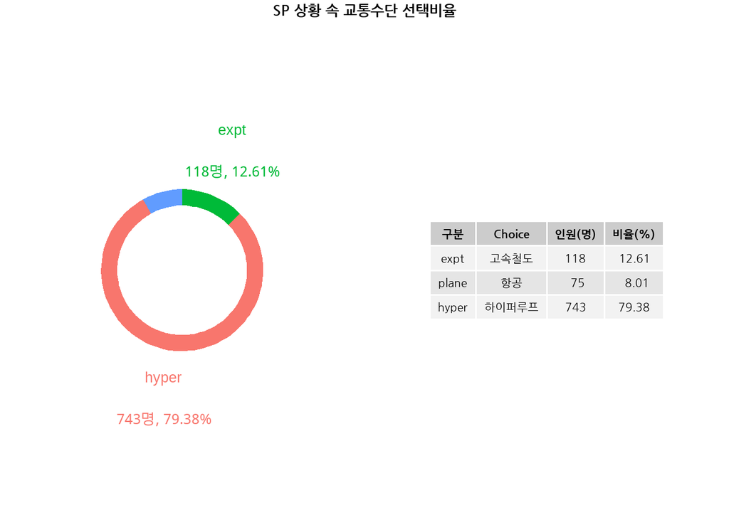

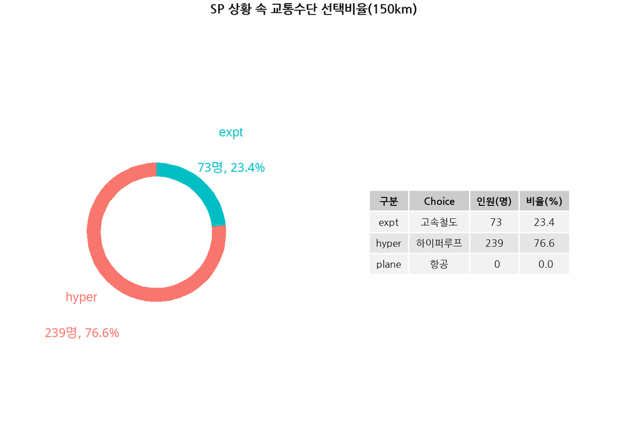

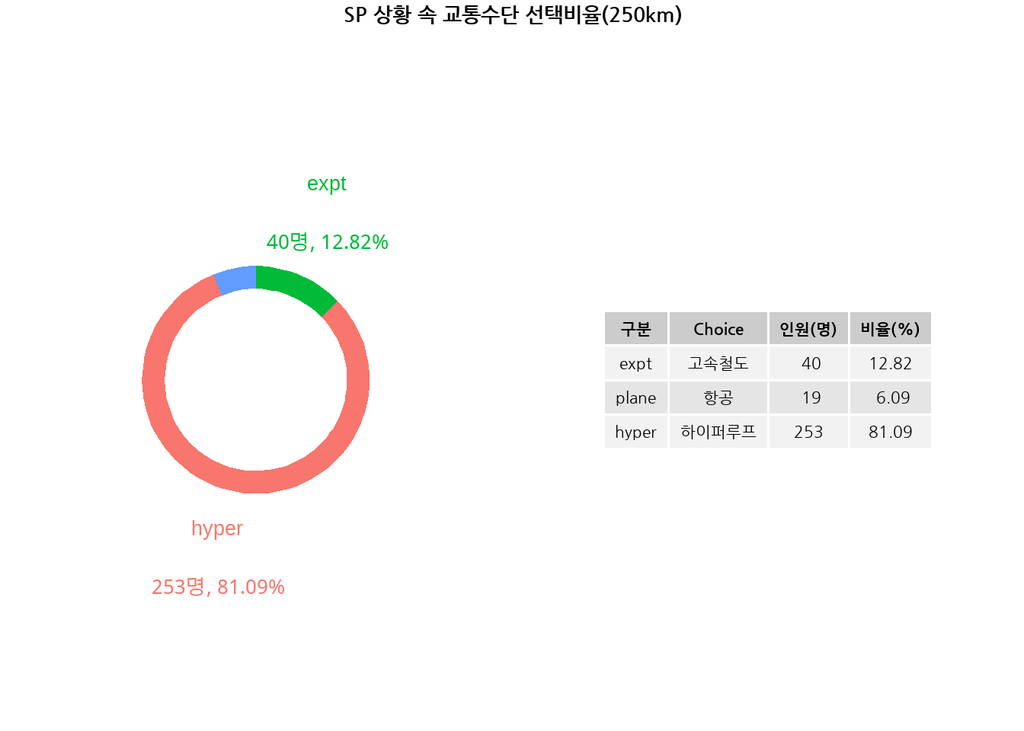

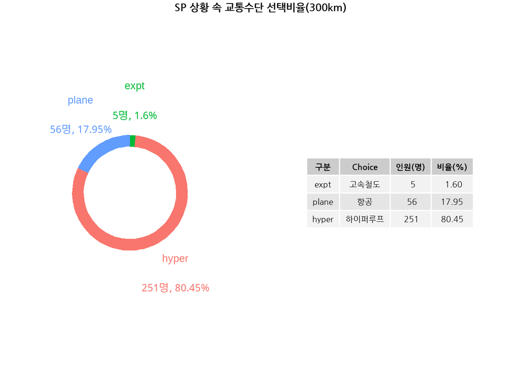

특이사항

- 150km에서 항공 선택 없음
- 300km에서 고속철도 선택 매우 적어 모형 구축 시 배제

### [거리별로 나눈] 모형 및 해석

```
##
## Call:
## mlogit(formula = Choice ~ Cost | Gender + HHsize + Job8 + Inc +
##     Ncars + AgeI + Trip_made + Conv + Eco + Safe + Trans + New +
##     Sens | Time, data = dtWide150, reflevel = "hyper", method = "nr")
##
## Frequencies of alternatives:choice
##   hyper    expt
## 0.76603 0.23397
##
## nr method
## 6 iterations, 0h:0m:0s
## g'(-H)^-1g = 0.000209
## successive function values within tolerance limits
##
## Coefficients :
##                     Estimate  Std. Error z-value  Pr(>|z|)
## (Intercept):expt -4.6205e+00  3.9817e+00 -1.1604   0.24587
## Cost             -1.9987e-04  3.2772e-05 -6.0987 1.069e-09 ***
## Gender:expt      -3.9914e-01  3.7604e-01 -1.0614   0.28850
## HHsize:expt       2.1696e-01  1.4951e-01  1.4511   0.14674
## Job8:expt        -1.0139e+00  7.2714e-01 -1.3944   0.16318
## Inc:expt         -2.2726e-01  2.5068e-01 -0.9066   0.36464
## Ncars:expt       -1.2434e+00  7.7049e-01 -1.6138   0.10657
## AgeI:expt         2.0014e-02  3.2639e-02  0.6132   0.53975
## Trip_made:expt    1.9227e-01  1.6215e-01  1.1857   0.23573
## Conv:expt        -1.9433e-01  1.7002e-01 -1.1430   0.25302
## Eco:expt          2.7401e-01  1.5216e-01  1.8008   0.07173 .
## Safe:expt        -2.2838e-02  1.5727e-01 -0.1452   0.88454
## Trans:expt       -1.0394e-01  1.2496e-01 -0.8318   0.40553
## New:expt         -2.2104e-01  1.2439e-01 -1.7769   0.07558 .
## Sens:expt        -2.4449e-01  1.2634e-01 -1.9352   0.05296 .
## Time:hyper       -6.1109e-02  4.0440e-02 -1.5111   0.13076
## Time:expt         2.3044e-02  3.3991e-02  0.6779   0.49781
## ---
## Signif. codes:  0 '***' 0.001 '**' 0.01 '*' 0.05 '.' 0.1 ' ' 1
##
## Log-Likelihood: -117.15
## McFadden R^2:  0.30983
## Likelihood ratio test : chisq = 105.18 (p.value = 3.6747e-15)
```

```
##
## Call:
## mlogit(formula = Choice ~ Cost | Gender + HHsize + Job8 + Inc +
##     Ncars + AgeI + Trip_made + Conv + Eco + Safe + Trans + New +
##     Sens | Time, data = dtWide250, reflevel = "hyper", method = "nr")
##
## Frequencies of alternatives:choice
##    hyper     expt    plane
## 0.810897 0.128205 0.060897
##
## nr method
## 8 iterations, 0h:0m:0s
## g'(-H)^-1g = 6.48E-06
## successive function values within tolerance limits
##
## Coefficients :
##                      Estimate  Std. Error z-value  Pr(>|z|)
## (Intercept):expt   2.6007e+01  6.8015e+00  3.8238 0.0001314 ***
## (Intercept):plane  4.1599e+01  1.2657e+01  3.2865 0.0010143 **
## Cost              -1.1278e-04  2.3692e-05 -4.7602 1.934e-06 ***
## Gender:expt        8.0593e-01  4.4047e-01  1.8297 0.0672929 .
## Gender:plane       6.0075e-01  7.0173e-01  0.8561 0.3919423
## HHsize:expt        2.6458e-01  1.8653e-01  1.4184 0.1560691
## HHsize:plane       4.1099e-01  2.7039e-01  1.5200 0.1285084
## Job8:expt         -2.3127e+00  1.0607e+00 -2.1804 0.0292277 *
## Job8:plane        -1.7500e+00  1.6589e+00 -1.0549 0.2914732
## Inc:expt          -1.0090e+00  4.5881e-01 -2.1990 0.0278751 *
## Inc:plane         -7.3133e-01  7.0317e-01 -1.0400 0.2983193
## Ncars:expt        -3.0505e-03  7.5802e-01 -0.0040 0.9967891
## Ncars:plane       -1.8109e+00  1.6040e+00 -1.1290 0.2589072
## AgeI:expt         -1.0031e-01  4.4320e-02 -2.2632 0.0236225 *
## AgeI:plane        -2.3981e-01  1.4372e-01 -1.6687 0.0951847 .
## Trip_made:expt     7.9714e-02  1.8973e-01  0.4201 0.6743800
## Trip_made:plane    5.3924e-01  3.3075e-01  1.6304 0.1030205
## Conv:expt          3.8063e-02  2.1465e-01  0.1773 0.8592523
## Conv:plane        -7.0717e-01  3.4060e-01 -2.0762 0.0378709 *
## Eco:expt           7.6478e-02  1.7477e-01  0.4376 0.6616820
## Eco:plane          5.1431e-01  3.0007e-01  1.7139 0.0865398 .
## Safe:expt         -2.1570e-01  1.8356e-01 -1.1751 0.2399616
## Safe:plane         2.5471e-01  3.3601e-01  0.7580 0.4484353
## Trans:expt         2.2515e-01  1.6700e-01  1.3482 0.1776044
## Trans:plane        6.1264e-01  3.2893e-01  1.8625 0.0625317 .
## New:expt           2.6091e-01  1.4965e-01  1.7434 0.0812615 .
## New:plane         -5.1129e-01  2.4996e-01 -2.0455 0.0408060 *
## Sens:expt         -2.3158e-01  1.5046e-01 -1.5391 0.1237677
## Sens:plane        -7.9891e-01  2.7527e-01 -2.9023 0.0037043 **
## Time:hyper         5.6619e-02  4.1543e-02  1.3629 0.1729131
## Time:expt         -1.6396e-01  4.4595e-02 -3.6765 0.0002364 ***
## Time:plane        -2.8202e-01  8.7153e-02 -3.2359 0.0012124 **
## ---
## Signif. codes:  0 '***' 0.001 '**' 0.01 '*' 0.05 '.' 0.1 ' ' 1
##
## Log-Likelihood: -132.07
## McFadden R^2:  0.29886
## Likelihood ratio test : chisq = 112.59 (p.value = 1.7294e-11)
```

```
##
## Call:
## mlogit(formula = Choice ~ Cost | Gender + HHsize + Job8 + Inc +
##     Ncars + AgeI + Trip_made + Conv + Eco + Safe + Trans + New +
##     Sens | Time, data = dtWide300, reflevel = "hyper", method = "nr")
##
## Frequencies of alternatives:choice
##   hyper   plane
## 0.81759 0.18241
##
## nr method
## 7 iterations, 0h:0m:0s
## g'(-H)^-1g = 2.15E-05
## successive function values within tolerance limits
##
## Coefficients :
##                      Estimate  Std. Error z-value  Pr(>|z|)
## (Intercept):plane  4.0025e+00  5.8436e+00  0.6849  0.493384
## Cost              -1.2090e-04  2.0418e-05 -5.9215 3.191e-09 ***
## Gender:plane       1.9478e+00  4.7999e-01  4.0580 4.949e-05 ***
## HHsize:plane      -1.3820e-01  1.6607e-01 -0.8322  0.405297
## Job8:plane        -2.6081e+00  8.4707e-01 -3.0790  0.002077 **
## Inc:plane         -8.5179e-01  3.0964e-01 -2.7509  0.005942 **
## Ncars:plane       -3.1099e+00  1.1480e+00 -2.7090  0.006748 **
## AgeI:plane         5.3391e-02  3.9753e-02  1.3430  0.179256
## Trip_made:plane    1.0395e-03  2.1112e-01  0.0049  0.996071
## Conv:plane        -1.4068e-01  2.2481e-01 -0.6257  0.531482
## Eco:plane          5.2839e-02  1.8137e-01  0.2913  0.770791
## Safe:plane        -2.8507e-01  1.8610e-01 -1.5318  0.125570
## Trans:plane       -1.1580e-01  1.4271e-01 -0.8114  0.417144
## New:plane         -3.1546e-01  1.4825e-01 -2.1279  0.033342 *
## Sens:plane         4.0906e-02  1.4808e-01  0.2763  0.782355
## Time:hyper        -2.7965e-02  3.6480e-02 -0.7666  0.443341
## Time:plane        -3.8541e-02  3.6559e-02 -1.0542  0.291776
## ---
## Signif. codes:  0 '***' 0.001 '**' 0.01 '*' 0.05 '.' 0.1 ' ' 1
##
## Log-Likelihood: -96.051
## McFadden R^2:  0.34136
## Likelihood ratio test : chisq = 99.565 (p.value = 4.1788e-14)
```

1. 공통
- 공통변수인 Cost는 모든 거리에서 유의하며, 음의 계수(-)인 것으로 보아 직관과 일치한다.
2. 150km
- 유의한 변수가 적은 이유는 아마도 너무 단거리이기 때문일 것이다.
3. 250km
- Intercept: 우리가 확인하지 못한 사항이 효용에 크게 영향을 미친다.
- Job8: ’무직, 학생’일수록 하이퍼루프 대비 고속철도의 선호 감소한다.

> 학생의 특성이 “저소득/젊은 연령”일 것이라는 편견이 있는데, 이를 반영해서 해석하면, ’설명변수는 서로 독립적이다’라는 가정에 위배되는 것이 아닐지 모르겠습니다.
- Inc: 고소득일수록 하이퍼루프 대비 고속철도의 선호 감소한다. 이는 고소득일수록 상대적으로 지불여유가 있기 때문일 것이다.
- AgeI: 연령대가 높을수록 하이퍼루프 대비 고속철도 및 항공 선호 감소한다(유의성 0.1 기준). 이때, 고속철도보다 항공의 선호가 더 크게 감소한다. 이는 연령대가 높을수록 과거 항공 경험이 흔치 않았기 때문일 것이다.
- Conv: 편의성을 중요시하는 사람일수록 하이퍼루프 대비 항공 선호 매우 크게 감소한다. 이는 항공의 편의성이 근본적으로 불편해서일 것이다.
- Eco, Trans:plane: 유의성 0.1 기준에서 친환경성과 환승 여부를 중요시하는 사람일수록 하이퍼루프 대비 항공의 선호가 증가하는데, 이는 하이퍼루프가 그러한 이미지를 지니고 있지 않음을 암시한다.
- New: 새로운 기술 사용 여부를 중요시할수록 하이퍼루프 대비 고속철도는 선호 증가(유의성 0.1 기준), 항공은 선호 감소이다. 이는 오랜 역사를 가진 항공 대비 하이퍼루프는 최신식인 반면, 고속철도와 하이퍼루프는 기술의 차이가 크게 느껴지지 않아서일 것이다.
- Sens: 감성을 중요시할수록 하이퍼루프 대비 항공의 선호는 감소한다. 이는 하이퍼루프가 감성적인 이미지를 지니고 있음을 암시한다.
4. 300km
- Gender:plane: 여자일수록 하이퍼루프 대비 항공기 선호 증가한다.
- Job8:plane: ’무직, 학생’일수록 하이퍼루프 대비 항공기 선호 감소한다.
- Inc:plane: 고소득일수록 하이퍼루프 대비 항공기 선호 감소한다. [250km 해석과 동일]
- Ncars:plane: 승용차를 보유하는 사람은 하이퍼루프 대비 항공기 선호 감소한다.

> 아무리 생각해봐도 승용차 보유와 장거리 교통수단 사이의 연관성은 적어 보이는데, 유의하다고 나와서 어떻게 해석해야 할지 모르겠습니다.
- New:plane: 최신 기술을 중요시하는 사람은 하이퍼루프 대비 항공기 선호 감소한다. [250km 해석과 동일]

### [거리를 모형 내에 포함한] 모형 및 해석

```
##
## Call:
## mlogit(formula = Choice ~ Cost | Gender + HHsize + Job8 + Inc +
##     Ncars + AgeI + Trip_made + Conv + Eco + Safe + Trans + New +
##     Sens | Time, data = dtWide, reflevel = "hyper", method = "nr")
##
## Frequencies of alternatives:choice
##    hyper     expt    plane
## 0.793803 0.126068 0.080128
##
## nr method
## 7 iterations, 0h:0m:0s
## g'(-H)^-1g = 1.21E-05
## successive function values within tolerance limits
##
## Coefficients :
##                      Estimate  Std. Error  z-value  Pr(>|z|)
## (Intercept):expt   1.6795e+00  1.3329e+00   1.2601 0.2076277
## (Intercept):plane  2.6563e+00  3.3404e+00   0.7952 0.4265062
## Cost              -1.1854e-04  1.0626e-05 -11.1562 < 2.2e-16 ***
## Gender:expt       -4.2937e-02  2.5239e-01  -0.1701 0.8649155
## Gender:plane       1.2329e+00  3.2880e-01   3.7497 0.0001771 ***
## HHsize:expt        1.6127e-01  1.0169e-01   1.5859 0.1127589
## HHsize:plane       6.9895e-02  1.2967e-01   0.5390 0.5898729
## Job8:expt         -1.3592e+00  5.0602e-01  -2.6860 0.0072320 **
## Job8:plane        -2.2685e+00  6.6000e-01  -3.4371 0.0005880 ***
## Inc:expt          -3.5316e-01  1.8648e-01  -1.8938 0.0582496 .
## Inc:plane         -6.6020e-01  2.5270e-01  -2.6126 0.0089847 **
## Ncars:expt        -8.4644e-01  4.9672e-01  -1.7041 0.0883680 .
## Ncars:plane       -2.3846e+00  8.3480e-01  -2.8565 0.0042830 **
## AgeI:expt         -1.2199e-02  2.2124e-02  -0.5514 0.5813737
## AgeI:plane         1.4542e-02  3.1490e-02   0.4618 0.6442241
## Trip_made:expt     1.4313e-01  1.0754e-01   1.3309 0.1832149
## Trip_made:plane    1.2573e-01  1.5407e-01   0.8160 0.4144798
## Conv:expt         -1.3715e-01  1.1606e-01  -1.1817 0.2373322
## Conv:plane        -2.8226e-01  1.7070e-01  -1.6535 0.0982326 .
## Eco:expt           2.0890e-01  1.0137e-01   2.0607 0.0393297 *
## Eco:plane          1.6082e-01  1.4003e-01   1.1485 0.2507792
## Safe:expt         -6.0408e-02  1.0667e-01  -0.5663 0.5711997
## Safe:plane        -8.4786e-02  1.4712e-01  -0.5763 0.5644210
## Trans:expt        -9.1904e-03  8.6570e-02  -0.1062 0.9154539
## Trans:plane        1.3962e-02  1.1972e-01   0.1166 0.9071573
## New:expt          -5.1158e-02  8.2928e-02  -0.6169 0.5372980
## New:plane         -3.0345e-01  1.1308e-01  -2.6836 0.0072838 **
## Sens:expt         -2.0079e-01  8.4532e-02  -2.3753 0.0175359 *
## Sens:plane        -2.0285e-01  1.1575e-01  -1.7524 0.0797041 .
## Time:hyper        -3.7512e-02  1.8662e-02  -2.0101 0.0444182 *
## Time:expt         -2.7941e-02  3.9613e-03  -7.0535 1.745e-12 ***
## Time:plane        -3.2885e-02  2.1707e-02  -1.5150 0.1297810
## ---
## Signif. codes:  0 '***' 0.001 '**' 0.01 '*' 0.05 '.' 0.1 ' ' 1
##
## Log-Likelihood: -425.45
## McFadden R^2:  0.29707
## Likelihood ratio test : chisq = 359.6 (p.value = < 2.22e-16)
```

```
##
## Call:
## mlogit(formula = Choice ~ Cost | Gender + HHsize + Job8 + Inc +
##     Ncars + AgeI + Trip_made + Conv + Eco + Safe + Trans + New +
##     Sens | TimeToDist, data = dtWide, reflevel = "hyper", method = "nr")
##
## Frequencies of alternatives:choice
##    hyper     expt    plane
## 0.793803 0.126068 0.080128
##
## nr method
## 8 iterations, 0h:0m:0s
## g'(-H)^-1g = 0.000456
## successive function values within tolerance limits
##
## Coefficients :
##                      Estimate  Std. Error  z-value  Pr(>|z|)
## (Intercept):expt   3.4048e+00  2.2152e+00   1.5370 0.1242928
## (Intercept):plane  5.1431e+00  2.4551e+00   2.0949 0.0361822 *
## Cost              -1.0184e-04  9.4595e-06 -10.7657 < 2.2e-16 ***
## Gender:expt       -5.6934e-02  2.5060e-01  -0.2272 0.8202756
## Gender:plane       1.2404e+00  3.3285e-01   3.7267 0.0001940 ***
## HHsize:expt        1.5773e-01  1.0106e-01   1.5607 0.1186043
## HHsize:plane       6.9091e-02  1.3100e-01   0.5274 0.5978971
## Job8:expt         -1.3535e+00  5.0208e-01  -2.6959 0.0070206 **
## Job8:plane        -2.3597e+00  6.7368e-01  -3.5027 0.0004606 ***
## Inc:expt          -3.4372e-01  1.8575e-01  -1.8504 0.0642533 .
## Inc:plane         -6.6599e-01  2.5459e-01  -2.6159 0.0088993 **
## Ncars:expt        -8.3252e-01  4.9151e-01  -1.6938 0.0903020 .
## Ncars:plane       -2.4470e+00  8.5295e-01  -2.8688 0.0041200 **
## AgeI:expt         -1.2100e-02  2.1963e-02  -0.5510 0.5816644
## AgeI:plane         1.4435e-02  3.1887e-02   0.4527 0.6507693
## Trip_made:expt     1.3728e-01  1.0675e-01   1.2861 0.1984165
## Trip_made:plane    1.1613e-01  1.5570e-01   0.7459 0.4557572
## Conv:expt         -1.3275e-01  1.1491e-01  -1.1552 0.2480021
## Conv:plane        -2.9480e-01  1.7349e-01  -1.6992 0.0892788 .
## Eco:expt           2.0448e-01  1.0038e-01   2.0371 0.0416414 *
## Eco:plane          1.7135e-01  1.4258e-01   1.2018 0.2294470
## Safe:expt         -6.0461e-02  1.0578e-01  -0.5716 0.5676147
## Safe:plane        -8.4972e-02  1.5002e-01  -0.5664 0.5711175
## Trans:expt        -1.3812e-02  8.5704e-02  -0.1612 0.8719668
## Trans:plane        1.3929e-02  1.2200e-01   0.1142 0.9090991
## New:expt          -5.1871e-02  8.2373e-02  -0.6297 0.5288836
## New:plane         -3.1845e-01  1.1536e-01  -2.7605 0.0057716 **
## Sens:expt         -1.9746e-01  8.3859e-02  -2.3547 0.0185388 *
## Sens:plane        -2.0621e-01  1.1735e-01  -1.7572 0.0788764 .
## TimeToDist:hyper  -1.2704e+01  1.8950e+00  -6.7039 2.029e-11 ***
## TimeToDist:expt   -1.0693e+01  3.3410e+00  -3.2006 0.0013714 **
## TimeToDist:plane  -1.4267e+01  3.6900e+00  -3.8663 0.0001105 ***
## ---
## Signif. codes:  0 '***' 0.001 '**' 0.01 '*' 0.05 '.' 0.1 ' ' 1
##
## Log-Likelihood: -423.84
## McFadden R^2:  0.29974
## Likelihood ratio test : chisq = 362.83 (p.value = < 2.22e-16)
```

```
##
## Call:
## mlogit(formula = Choice ~ Cost | Gender + HHsize + Job8 + Inc +
##     Ncars + AgeI + Trip_made + Conv + Eco + Safe + Trans + New +
##     Sens | Time + TimeToDist, data = dtWide, reflevel = "hyper",
##     method = "nr")
##
## Frequencies of alternatives:choice
##    hyper     expt    plane
## 0.793803 0.126068 0.080128
##
## nr method
## 8 iterations, 0h:0m:0s
## g'(-H)^-1g = 0.000416
## successive function values within tolerance limits
##
## Coefficients :
##                      Estimate  Std. Error  z-value  Pr(>|z|)
## (Intercept):expt   5.0948e+00  2.4095e+00   2.1145 0.0344761 *
## (Intercept):plane  1.2098e+01  4.7052e+00   2.5711 0.0101383 *
## Cost              -1.1250e-04  1.0940e-05 -10.2834 < 2.2e-16 ***
## Gender:expt       -6.0352e-02  2.4976e-01  -0.2416 0.8090568
## Gender:plane       1.2906e+00  3.3861e-01   3.8113 0.0001382 ***
## HHsize:expt        1.5661e-01  1.0066e-01   1.5558 0.1197575
## HHsize:plane       6.9978e-02  1.3268e-01   0.5274 0.5979045
## Job8:expt         -1.3108e+00  5.0098e-01  -2.6165 0.0088828 **
## Job8:plane        -2.3846e+00  6.8381e-01  -3.4872 0.0004881 ***
## Inc:expt          -3.3841e-01  1.8488e-01  -1.8304 0.0671881 .
## Inc:plane         -6.8350e-01  2.5764e-01  -2.6529 0.0079800 **
## Ncars:expt        -8.0681e-01  4.9047e-01  -1.6450 0.0999776 .
## Ncars:plane       -2.4993e+00  8.6750e-01  -2.8810 0.0039642 **
## AgeI:expt         -1.1976e-02  2.1893e-02  -0.5470 0.5843663
## AgeI:plane         1.5044e-02  3.2225e-02   0.4668 0.6406145
## Trip_made:expt     1.3896e-01  1.0641e-01   1.3059 0.1915838
## Trip_made:plane    1.2206e-01  1.5725e-01   0.7762 0.4376074
## Conv:expt         -1.2932e-01  1.1471e-01  -1.1274 0.2595809
## Conv:plane        -2.9771e-01  1.7609e-01  -1.6907 0.0909022 .
## Eco:expt           2.0155e-01  1.0018e-01   2.0119 0.0442312 *
## Eco:plane          1.7027e-01  1.4455e-01   1.1779 0.2388310
## Safe:expt         -5.9137e-02  1.0541e-01  -0.5610 0.5747866
## Safe:plane        -8.7814e-02  1.5216e-01  -0.5771 0.5638517
## Trans:expt        -1.2094e-02  8.5511e-02  -0.1414 0.8875250
## Trans:plane        1.7611e-02  1.2366e-01   0.1424 0.8867511
## New:expt          -4.6607e-02  8.2021e-02  -0.5682 0.5698794
## New:plane         -3.2212e-01  1.1692e-01  -2.7550 0.0058687 **
## Sens:expt         -1.9490e-01  8.3595e-02  -2.3314 0.0197314 *
## Sens:plane        -2.0781e-01  1.1902e-01  -1.7460 0.0808089 .
## Time:hyper        -1.5235e-02  5.1858e-02  -0.2938 0.7689165
## Time:expt         -2.2852e-02  1.9720e-02  -1.1588 0.2465428
## Time:plane        -5.6847e-02  3.0022e-02  -1.8935 0.0582908 .
## TimeToDist:hyper  -1.0735e+00  9.7183e+00  -0.1105 0.9120398
## TimeToDist:expt   -5.4886e+00  5.6645e+00  -0.9689 0.3325741
## TimeToDist:plane  -1.0525e+01  5.8126e+00  -1.8107 0.0701889 .
## ---
## Signif. codes:  0 '***' 0.001 '**' 0.01 '*' 0.05 '.' 0.1 ' ' 1
##
## Log-Likelihood: -418.77
## McFadden R^2:  0.30811
## Likelihood ratio test : chisq = 372.97 (p.value = < 2.22e-16)
```

> 이런 비선형적인 변수는 어떻게 해석해야 할 지 모르겠습니다.
4. 시간 + 거리 대비 시간
- 위와 유사한 경향을 보이지만, Time과 TimeToDist의 유의성이 급격하게 감소